# Parasite_BodyPreference_MultivariateAnalysis_Main

**Multivariate Analysis comparing the average distribution of parasites for different body regions across parasite-fish combinations at each time point**

```python
options(repr.plot.width=8, repr.plot.height=8,repr.plot.res = 300) #Setting plot size
```

```python
#Installing packages
library(dplyr)
library(MASS)
library(plotly)
library(ggplot2)
library(lattice)
library(tidyverse) #for data transformation
library(magrittr) #for piping
library(forcats) #for factor manipulation
#library("devtools")
library("yarrr")
library(gganimate)
library(gapminder)
library(gifski)


library("rms")
#library("sjPlot")#Interaction plots
library(sjmisc)
library(ggplot2)
library(MuMIn) # use to calculate the marginal and conditional R-Sq
library(lme4) #for glmm
library("lmerTest")
library(effects)#check for effect size
#theme_set(theme_sjplot())


library("pROC")
library("psych")
library("rockchalk")
library(ROCR)
#Loading packages
library(rpart)
library(rpart.plot)
library(caret)
library("randomForest") #for categorical dependent variable
library("mobForest") #for random forest (eg. count data)
#library("REEMtree") #classification tree with random effect

#library(tidyr)
library(reshape2)
#library(reprtree) #for ploting random forest tree
library("gbm") #Gradient boosting machine
#library("dismo")
library(xgboost)      # a faster implementation of gbm
library(pdp)          # model visualization
library(ggplot2)      # model visualization
library(lime)         # model visualization
library("factoextra")
library("cluster")
library("mclust") #model-based clustering
library("dbscan")#density-based clustering
library("clValid")#Validate Clustering methods
library("kohonen") #Self-organising maps  clustering
library(NbClust) #determining the optimal number of clusters
library (fpc)

library(mlbench)
library(e1071)
library("ggpubr")
#Visualizing randomforest
library(igraph)
library("plyr")
library("lubridate")
library(dplyr)
library("ggraph")
library("rminer")

#Visualizing gbm (convert rf and ct to gbm)
library("partykit")
#library("h2o")
library("nnet")

#Create a custom color scale
library(RColorBrewer)
#library(fishplot)

library(sp)  # vector data
#library(raster)  # raster data
library(rgdal)  # input/output, projections

library("rgeos")  # geometry ops
#library("spdep")  # spatial dependence
library(maptools)

#Multivariate analysis
library(mvtnorm)
#library(MVN)
#library("Hotelling")
#library("mvnormtest")
#library("heplots")
#library(lattice)
#library(Matrix)

#For Non-parametric pairwise comparison
library("PMCMRplus")

library(ggplot2)
library(gridExtra)
library(grid)
library(cowplot)
library(ggpattern)
```

```python
#Importing data
Gt3_plot=read.csv(file="GT3_Plot_2.csv")
Gt_plot=read.csv(file="LA-Turn_Plot_2.csv")
Gbull_plot=read.csv(file="LA-Bull_plot_2.csv")

Fish_strain_Gt3=factor(Gt3_plot$Pop_strain,levels=c(1,2,3), labels=c("UA", "LA","Orn"))
Fish_sex_Gt3=factor(Gt3_plot$SEX,levels=c(1,2), labels=c("Female", "Male"))

Gt3_plot$fish=Fish_strain_Gt3
Gt3_plot$Fish_sex=Fish_sex_Gt3
Gt3_plot$parasite_type=rep(1,dim(Gt3_plot)[1])


Fish_strain_Gt=factor(Gt_plot$Pop_strain,levels=c(1,2,3), labels=c("UA", "LA","Orn"))
Fish_sex_Gt=factor(Gt_plot$SEX,levels=c(1,2), labels=c("Female", "Male"))

Gt_plot$fish=Fish_strain_Gt
Gt_plot$Fish_sex=Fish_sex_Gt
Gt_plot$parasite_type=rep(2,dim(Gt_plot)[1])


Fish_strain_Gbull=factor(Gbull_plot$Pop_strain,levels=c(1,2,3), labels=c("UA", "LA","Orn"))
Fish_sex_Gbull=factor(Gbull_plot$SEX,levels=c(1,2), labels=c("Female", "Male"))

Gbull_plot$fish=Fish_strain_Gbull
Gbull_plot$Fish_sex=Fish_sex_Gbull
Gbull_plot$parasite_type=rep(3,dim(Gbull_plot)[1])

#Combining the three data set
Combined_data<-rbind(Gt3_plot,Gt_plot,Gbull_plot)
Combined_data$Pop_strain<-factor(Combined_data$Pop_strain,levels=c(1,2,3), labels=c("UA", "LA","Orn"))
Combined_data$parasite_type<-factor(Combined_data$parasite_type,levels=c(1,2,3),labels=c("Gt3","Gt","Gbull"))
Orn_plot=split(Combined_data,Combined_data$Pop_strain)$"Orn"
LA_plot=split(Combined_data,Combined_data$Pop_strain)$"LA"
UA_plot=split(Combined_data,Combined_data$Pop_strain)$"UA"

#Transforming the data structure for Time-based HeatMap
Parasite_transform=list()
Parasite_transform[[1]]<- ddply(Gt3_plot, c("Day", "Parasite","Bodypart"), summarise,
                    N    = length(Gt3_plot)
)

Parasite_transform[[2]]<- ddply(Gt_plot, c("Day", "Parasite","Bodypart"), summarise,
                    N    = length(Gt_plot)
)

Parasite_transform[[3]]<- ddply(Gbull_plot, c("Day", "Parasite","Bodypart"), summarise,
                    N    = length(Gbull_plot)
)


Parasite_transform[[4]]<- ddply(Orn_plot, c("Day", "Parasite","Bodypart"), summarise,
                    N    = length(Gt3_plot)
)

Parasite_transform[[5]]<- ddply(LA_plot, c("Day", "Parasite","Bodypart"), summarise,
                    N    = length(Gt_plot)
)

Parasite_transform[[6]]<- ddply(UA_plot, c("Day", "Parasite","Bodypart"), summarise,
                    N    = length(Gbull_plot)
)

Parasite_transform[[1]]$Bodypart= factor(Parasite_transform[[1]]$Bodypart,levels(Parasite_transform[[1]]$Bodypart)[c(7,4,8,1,2,6,5,3)])
Parasite_transform[[2]]$Bodypart= factor(Parasite_transform[[2]]$Bodypart,levels(Parasite_transform[[2]]$Bodypart)[c(7,4,8,1,2,6,5,3)])
Parasite_transform[[3]]$Bodypart= factor(Parasite_transform[[3]]$Bodypart,levels(Parasite_transform[[3]]$Bodypart)[c(7,4,8,1,2,6,5,3)])
Parasite_transform[[4]]$Bodypart= factor(Parasite_transform[[4]]$Bodypart,levels(Parasite_transform[[4]]$Bodypart)[c(7,4,8,1,2,6,5,3)])
Parasite_transform[[5]]$Bodypart= factor(Parasite_transform[[5]]$Bodypart,levels(Parasite_transform[[5]]$Bodypart)[c(7,4,8,1,2,6,5,3)])
Parasite_transform[[6]]$Bodypart= factor(Parasite_transform[[6]]$Bodypart,levels(Parasite_transform[[6]]$Bodypart)[c(7,4,8,1,2,6,5,3)])


#levels(Parasite_transform_Gt3$Bodypart)
#levels(Parasite_transform_Gt$Bodypart)
#levels(Parasite_transform_Gbull$Bodypart)
```

**Splitting data across parasite type and days of infection for each fish type**

```python
#Ornamental fish across parasite type
Orn_Gt3_data=split(Orn_plot,Orn_plot$parasite_type)$Gt3
Orn_Gt_data=split(Orn_plot,Orn_plot$parasite_type)$Gt
Orn_Gbull_data=split(Orn_plot,Orn_plot$parasite_type)$Gbull

#LA fish across parasite type
LA_Gt3_data=split(LA_plot,LA_plot$parasite_type)$Gt3
LA_Gt_data=split(LA_plot,LA_plot$parasite_type)$Gt
LA_Gbull_data=split(LA_plot,LA_plot$parasite_type)$Gbull

#UA fish across parasite type
UA_Gt3_data=split(UA_plot,UA_plot$parasite_type)$Gt3
UA_Gt_data=split(UA_plot,UA_plot$parasite_type)$Gt
UA_Gbull_data=split(UA_plot,UA_plot$parasite_type)$Gbull
```

**Splitting across time for Ornamental fish and each parasite type**

```python
#Splitting across time for Orn-Gt3
Orn_Gt3=list()
Orn_Gt3[[1]]=split(Orn_Gt3_data,Orn_Gt3_data$Day)$"1"
Orn_Gt3[[3]]=split(Orn_Gt3_data,Orn_Gt3_data$Day)$"3"
Orn_Gt3[[5]]=split(Orn_Gt3_data,Orn_Gt3_data$Day)$"5"
Orn_Gt3[[7]]=split(Orn_Gt3_data,Orn_Gt3_data$Day)$"7"
Orn_Gt3[[9]]=split(Orn_Gt3_data,Orn_Gt3_data$Day)$"9"
Orn_Gt3[[11]]=split(Orn_Gt3_data,Orn_Gt3_data$Day)$"11"
Orn_Gt3[[13]]=split(Orn_Gt3_data,Orn_Gt3_data$Day)$"13"
Orn_Gt3[[15]]=split(Orn_Gt3_data,Orn_Gt3_data$Day)$"15"
Orn_Gt3[[17]]=split(Orn_Gt3_data,Orn_Gt3_data$Day)$"17"

#Splitting across time for Orn-Gt
Orn_Gt=list()
Orn_Gt[[1]]=split(Orn_Gt_data,Orn_Gt_data$Day)$"1"
Orn_Gt[[3]]=split(Orn_Gt_data,Orn_Gt_data$Day)$"3"
Orn_Gt[[5]]=split(Orn_Gt_data,Orn_Gt_data$Day)$"5"
Orn_Gt[[7]]=split(Orn_Gt_data,Orn_Gt_data$Day)$"7"
Orn_Gt[[9]]=split(Orn_Gt_data,Orn_Gt_data$Day)$"9"
Orn_Gt[[11]]=split(Orn_Gt_data,Orn_Gt_data$Day)$"11"
Orn_Gt[[13]]=split(Orn_Gt_data,Orn_Gt_data$Day)$"13"
Orn_Gt[[15]]=split(Orn_Gt_data,Orn_Gt_data$Day)$"15"
Orn_Gt[[17]]=split(Orn_Gt_data,Orn_Gt_data$Day)$"17"


#Splitting across time for Orn-Gbull
Orn_Gbull=list()
Orn_Gbull[[1]]=split(Orn_Gbull_data,Orn_Gbull_data$Day)$"1"
Orn_Gbull[[3]]=split(Orn_Gbull_data,Orn_Gbull_data$Day)$"3"
Orn_Gbull[[5]]=split(Orn_Gbull_data,Orn_Gbull_data$Day)$"5"
Orn_Gbull[[7]]=split(Orn_Gbull_data,Orn_Gbull_data$Day)$"7"
Orn_Gbull[[9]]=split(Orn_Gbull_data,Orn_Gbull_data$Day)$"9"
Orn_Gbull[[11]]=split(Orn_Gbull_data,Orn_Gbull_data$Day)$"11"
Orn_Gbull[[13]]=split(Orn_Gbull_data,Orn_Gbull_data$Day)$"13"
Orn_Gbull[[15]]=split(Orn_Gbull_data,Orn_Gbull_data$Day)$"15"
Orn_Gbull[[17]]=split(Orn_Gbull_data,Orn_Gbull_data$Day)$"17"
```

**Splitting across time for LA fish and each parasite type**

```python
#Splitting across time for LA-Gt3
LA_Gt3=list()
LA_Gt3[[1]]=split(LA_Gt3_data,LA_Gt3_data$Day)$"1"
LA_Gt3[[3]]=split(LA_Gt3_data,LA_Gt3_data$Day)$"3"
LA_Gt3[[5]]=split(LA_Gt3_data,LA_Gt3_data$Day)$"5"
LA_Gt3[[7]]=split(LA_Gt3_data,LA_Gt3_data$Day)$"7"
LA_Gt3[[9]]=split(LA_Gt3_data,LA_Gt3_data$Day)$"9"
LA_Gt3[[11]]=split(LA_Gt3_data,LA_Gt3_data$Day)$"11"
LA_Gt3[[13]]=split(LA_Gt3_data,LA_Gt3_data$Day)$"13"
LA_Gt3[[15]]=split(LA_Gt3_data,LA_Gt3_data$Day)$"15"
LA_Gt3[[17]]=split(LA_Gt3_data,LA_Gt3_data$Day)$"17"

#Splitting across time for LA-Gt
LA_Gt=list()
LA_Gt[[1]]=split(LA_Gt_data,LA_Gt_data$Day)$"1"
LA_Gt[[3]]=split(LA_Gt_data,LA_Gt_data$Day)$"3"
LA_Gt[[5]]=split(LA_Gt_data,LA_Gt_data$Day)$"5"
LA_Gt[[7]]=split(LA_Gt_data,LA_Gt_data$Day)$"7"
LA_Gt[[9]]=split(LA_Gt_data,LA_Gt_data$Day)$"9"
LA_Gt[[11]]=split(LA_Gt_data,LA_Gt_data$Day)$"11"
LA_Gt[[13]]=split(LA_Gt_data,LA_Gt_data$Day)$"13"
LA_Gt[[15]]=split(LA_Gt_data,LA_Gt_data$Day)$"15"
LA_Gt[[17]]=split(LA_Gt_data,LA_Gt_data$Day)$"17"


#Splitting across time for LA-Gbull
LA_Gbull=list()
LA_Gbull[[1]]=split(LA_Gbull_data,LA_Gbull_data$Day)$"1"
LA_Gbull[[3]]=split(LA_Gbull_data,LA_Gbull_data$Day)$"3"
LA_Gbull[[5]]=split(LA_Gbull_data,LA_Gbull_data$Day)$"5"
LA_Gbull[[7]]=split(LA_Gbull_data,LA_Gbull_data$Day)$"7"
LA_Gbull[[9]]=split(LA_Gbull_data,LA_Gbull_data$Day)$"9"
LA_Gbull[[11]]=split(LA_Gbull_data,LA_Gbull_data$Day)$"11"
LA_Gbull[[13]]=split(LA_Gbull_data,LA_Gbull_data$Day)$"13"
LA_Gbull[[15]]=split(LA_Gbull_data,LA_Gbull_data$Day)$"15"
LA_Gbull[[17]]=split(LA_Gbull_data,LA_Gbull_data$Day)$"17"
```

**Splitting across time for UA fish and each parasite type**

```python
#Splitting across time for UA-Gt3
UA_Gt3=list()
UA_Gt3[[1]]=split(UA_Gt3_data,UA_Gt3_data$Day)$"1"
UA_Gt3[[3]]=split(UA_Gt3_data,UA_Gt3_data$Day)$"3"
UA_Gt3[[5]]=split(UA_Gt3_data,UA_Gt3_data$Day)$"5"
UA_Gt3[[7]]=split(UA_Gt3_data,UA_Gt3_data$Day)$"7"
UA_Gt3[[9]]=split(UA_Gt3_data,UA_Gt3_data$Day)$"9"
UA_Gt3[[11]]=split(UA_Gt3_data,UA_Gt3_data$Day)$"11"
UA_Gt3[[13]]=split(UA_Gt3_data,UA_Gt3_data$Day)$"13"
UA_Gt3[[15]]=split(UA_Gt3_data,UA_Gt3_data$Day)$"15"
UA_Gt3[[17]]=split(UA_Gt3_data,UA_Gt3_data$Day)$"17"

#Splitting across time for UA-Gt
UA_Gt=list()
UA_Gt[[1]]=split(UA_Gt_data,UA_Gt_data$Day)$"1"
UA_Gt[[3]]=split(UA_Gt_data,UA_Gt_data$Day)$"3"
UA_Gt[[5]]=split(UA_Gt_data,UA_Gt_data$Day)$"5"
UA_Gt[[7]]=split(UA_Gt_data,UA_Gt_data$Day)$"7"
UA_Gt[[9]]=split(UA_Gt_data,UA_Gt_data$Day)$"9"
UA_Gt[[11]]=split(UA_Gt_data,UA_Gt_data$Day)$"11"
UA_Gt[[13]]=split(UA_Gt_data,UA_Gt_data$Day)$"13"
UA_Gt[[15]]=split(UA_Gt_data,UA_Gt_data$Day)$"15"
UA_Gt[[17]]=split(UA_Gt_data,UA_Gt_data$Day)$"17"


#Splitting across time for UA-Gbull
UA_Gbull=list()
UA_Gbull[[1]]=split(UA_Gbull_data,UA_Gbull_data$Day)$"1"
UA_Gbull[[3]]=split(UA_Gbull_data,UA_Gbull_data$Day)$"3"
UA_Gbull[[5]]=split(UA_Gbull_data,UA_Gbull_data$Day)$"5"
UA_Gbull[[7]]=split(UA_Gbull_data,UA_Gbull_data$Day)$"7"
UA_Gbull[[9]]=split(UA_Gbull_data,UA_Gbull_data$Day)$"9"
UA_Gbull[[11]]=split(UA_Gbull_data,UA_Gbull_data$Day)$"11"
UA_Gbull[[13]]=split(UA_Gbull_data,UA_Gbull_data$Day)$"13"
UA_Gbull[[15]]=split(UA_Gbull_data,UA_Gbull_data$Day)$"15"
UA_Gbull[[17]]=split(UA_Gbull_data,UA_Gbull_data$Day)$"17"
```

**Transforming the 81 different data structure for heatmap**

```python
seq_day=seq(1,17,by=2)
Trans_Orn_Gt3=list()
Trans_Orn_Gt=list()
Trans_Orn_Gbull=list()
Trans_LA_Gt3=list()
Trans_LA_Gt=list()
Trans_LA_Gbull=list()
Trans_UA_Gt3=list()
Trans_UA_Gt=list()
Trans_UA_Gbull=list()
for (i in seq_day)
    {
Trans_Orn_Gt3[[i]]<- ddply(Orn_Gt3[[i]], c("Day", "Parasite","Bodypart","ID"), summarise,
                    N    = length(Orn_Gt3))
Trans_Orn_Gt[[i]]<- ddply(Orn_Gt[[i]], c("Day", "Parasite","Bodypart","ID"), summarise,
                    N    = length(Orn_Gt))
Trans_Orn_Gbull[[i]]<- ddply(Orn_Gbull[[i]], c("Day", "Parasite","Bodypart","ID"), summarise,
                    N    = length(Orn_Gbull))

Trans_LA_Gt3[[i]]<- ddply(LA_Gt3[[i]], c("Day", "Parasite","Bodypart","ID"), summarise,
                    N    = length(LA_Gt3))
Trans_LA_Gt[[i]]<- ddply(LA_Gt[[i]], c("Day", "Parasite","Bodypart","ID"), summarise,
                    N    = length(LA_Gt))
Trans_LA_Gbull[[i]]<- ddply(LA_Gbull[[i]], c("Day", "Parasite","Bodypart","ID"), summarise,
                    N    = length(LA_Gbull))

Trans_UA_Gt3[[i]]<- ddply(UA_Gt3[[i]], c("Day", "Parasite","Bodypart","ID"), summarise,
                    N    = length(UA_Gt3))
Trans_UA_Gt[[i]]<- ddply(UA_Gt[[i]], c("Day", "Parasite","Bodypart","ID"), summarise,
                    N    = length(UA_Gt))
Trans_UA_Gbull[[i]]<- ddply(UA_Gbull[[i]], c("Day", "Parasite","Bodypart","ID"), summarise,
                    N    = length(UA_Gbull))
}
```

**Creating a function to transform the data for Multivariate analysis**

```python
#Function to transform data for multivariate analysis
Catogories=c("Gt3-Orn","Gt3-LA","Gt3-UA","Gt-Orn","Gt-LA","Gt-UA","Gb-Orn","Gb-LA","Gb-UA")
Time=seq(1,17,by=2)
Bodyparts=list()
Dataframe_Gyro=function(Data,Group_no,time_index){
Bodyparts[[1]]=split(Data[,-c(1,4)],Data$Bodypart)$"Tail"
Bodyparts[[2]]=split(Data[,-c(1,4)],Data$Bodypart)$"Anal"
Bodyparts[[3]]=split(Data[,-c(1,4)],Data$Bodypart)$"LB"
Bodyparts[[4]]=split(Data[,-c(1,4)],Data$Bodypart)$"UB"
Bodyparts[[5]]=split(Data[,-c(1,4)],Data$Bodypart)$"Pelvic"
Bodyparts[[6]]=split(Data[,-c(1,4)],Data$Bodypart)$"Pectoral"
Bodyparts[[7]]=split(Data[,-c(1,4)],Data$Bodypart)$"Dorsal"
Bodyparts[[8]]=split(Data[,-c(1,4)],Data$Bodypart)$"Head"

Tail=as.vector(Bodyparts[[1]]$Parasite)
Anal=as.vector(Bodyparts[[2]]$Parasite)
LB=as.vector(Bodyparts[[3]]$Parasite)
UB=as.vector(Bodyparts[[4]]$Parasite)
Pelvic=as.vector(Bodyparts[[5]]$Parasite)
Pectoral=as.vector(Bodyparts[[6]]$Parasite)
Dorsal=as.vector(Bodyparts[[7]]$Parasite)
Head=as.vector(Bodyparts[[8]]$Parasite)
Category=rep(Catogories[Group_no],length(unique(Data$ID)))
time_variable=rep(time_index,length(unique(Data$ID)))
return(data.frame(Tail=Tail,Anal=Anal,LB=LB,UB=UB,Pelvic=Pelvic,Pectoral=Pectoral,Dorsal=Dorsal,Head=Head,
                 Group=Category,Day=time_variable))
}


#Function to combine transformed data
CombData_func=function(data1,data2,data3,data4,data5,data6,data7,data8,data9)
    {
    return(rbind(data1,data2,data3,data4,data5,data6,data7,data8,data9))
}
```

```python
#Transformed data for each time point
OrnGt3=list();LAGt3=list();UAGt3=list();OrnGt=list();LAGt=list();UAGt=list();OrnGbull=list();LAGbull=list();UAGbull=list()

for (i in Time)
    {
OrnGt3[[i]]=Dataframe_Gyro(Data=Trans_Orn_Gt3[[i]],Group_no=1,time_index=i)
LAGt3[[i]]=Dataframe_Gyro(Data=Trans_LA_Gt3[[i]],Group_no=2,time_index=i)
UAGt3[[i]]=Dataframe_Gyro(Data=Trans_UA_Gt3[[i]],Group_no=3,time_index=i)
OrnGt[[i]]=Dataframe_Gyro(Data=Trans_Orn_Gt[[i]],Group_no=4,time_index=i)
LAGt[[i]]=Dataframe_Gyro(Data=Trans_LA_Gt[[i]],Group_no=5,time_index=i)
UAGt[[i]]=Dataframe_Gyro(Data=Trans_UA_Gt[[i]],Group_no=6,time_index=i)
OrnGbull[[i]]=Dataframe_Gyro(Data=Trans_Orn_Gbull[[i]],Group_no=7,time_index=i)
LAGbull[[i]]=Dataframe_Gyro(Data=Trans_LA_Gbull[[i]],Group_no=8,time_index=i)
UAGbull[[i]]=Dataframe_Gyro(Data=Trans_UA_Gbull[[i]],Group_no=9,time_index=i)
}

#Combining data
MultiData=list()
for (i in Time){
MultiData[[i]]=CombData_func(data1=OrnGt3[[i]],data2=LAGt3[[i]],data3=UAGt3[[i]],
                             data4=OrnGt[[i]],data5=LAGt[[i]],data6=UAGt[[i]],
                             data7=OrnGbull[[i]],data8=LAGbull[[i]],data9=UAGbull[[i]])
}
```

**Function for mean load computation for Profile Plot**

```python
Bodyparts=list()
Guppy<-function(Data){
    #display.brewer.all(8,type="seq",colorblindFriendly=T)
Bodyparts[[1]]=split(Data[,-c(1,4)],Data$Bodypart)$"Tail"
Bodyparts[[2]]=split(Data[,-c(1,4)],Data$Bodypart)$"Anal"
Bodyparts[[3]]=split(Data[,-c(1,4)],Data$Bodypart)$"LB"
Bodyparts[[4]]=split(Data[,-c(1,4)],Data$Bodypart)$"UB"
Bodyparts[[5]]=split(Data[,-c(1,4)],Data$Bodypart)$"Pelvic"
Bodyparts[[6]]=split(Data[,-c(1,4)],Data$Bodypart)$"Pectoral"
Bodyparts[[7]]=split(Data[,-c(1,4)],Data$Bodypart)$"Dorsal"
Bodyparts[[8]]=split(Data[,-c(1,4)],Data$Bodypart)$"Head"

#Computing means across each of the bodyparts

fish_total=length(unique(Data$ID))
Tail=sum(Bodyparts[[1]]$Parasite)/fish_total
Anal=sum(Bodyparts[[2]]$Parasite)/fish_total
LB=sum(Bodyparts[[3]]$Parasite)/fish_total
UB=sum(Bodyparts[[4]]$Parasite)/fish_total
Pelvic=sum(Bodyparts[[5]]$Parasite)/fish_total
Pectoral=sum(Bodyparts[[6]]$Parasite)/fish_total
Dorsal=sum(Bodyparts[[7]]$Parasite)/fish_total
Head=sum(Bodyparts[[8]]$Parasite)/fish_total

return(c(Tail,Anal,LB,UB,Pelvic,Pectoral,Dorsal,Head))
}
```

```python
Gt3_Orn_heatmap=list()

for (i in seq_day){
 Gt3_Orn_heatmap[[i]]= Guppy(Trans_Orn_Gt3[[i]])
}

for (i in seq_day){
cat("Mean Parasite load of Orn fish for Gt3 at the eight bodyparts are for day:", "",i,"is","",Gt3_Orn_heatmap[[i]],"\n")
    }
```

```
Mean Parasite load of Orn fish for Gt3 at the eight bodyparts are for day:  1 is  1.285714 0 0 0 0.1428571 0 0.07142857 0
Mean Parasite load of Orn fish for Gt3 at the eight bodyparts are for day:  3 is  1.571429 0.07142857 0.07142857 0.1428571 0.3571429 0.4285714 0.2142857 0
Mean Parasite load of Orn fish for Gt3 at the eight bodyparts are for day:  5 is  2.785714 0.2857143 1.571429 0 0.9285714 0.2857143 0.4285714 0.07142857
Mean Parasite load of Orn fish for Gt3 at the eight bodyparts are for day:  7 is  2.785714 0.2857143 1.571429 0 0.9285714 0.2857143 0.4285714 0.07142857
Mean Parasite load of Orn fish for Gt3 at the eight bodyparts are for day:  9 is  12 0.4285714 10.21429 0.7142857 1.571429 2.071429 0.7142857 0.07142857
Mean Parasite load of Orn fish for Gt3 at the eight bodyparts are for day:  11 is  14.57143 2.142857 11.5 0.9285714 1.928571 1.285714 0.3571429 0.1428571
Mean Parasite load of Orn fish for Gt3 at the eight bodyparts are for day:  13 is  12.14286 1.5 7.357143 1.071429 1.285714 0.5714286 1.071429 0
Mean Parasite load of Orn fish for Gt3 at the eight bodyparts are for day:  15 is  11.61538 0.5384615 1.538462 7.538462 0.4615385 0.6153846 0.4615385 0.9230769
Mean Parasite load of Orn fish for Gt3 at the eight bodyparts are for day:  17 is  1.076923 0.1538462 0.2307692 0.2307692 0.2307692 0.07692308 0.07692308 0
```

```python
Gt_Orn_heatmap=list()

for (i in seq_day){
 Gt_Orn_heatmap[[i]]= Guppy(Trans_Orn_Gt[[i]])
}

for (i in seq_day){
cat("Mean parasite load of Orn fish  for Gt at the eight bodyparts are for day:", "",i,"is","",Gt_Orn_heatmap[[i]],"\n")
    }
```

```
Mean parasite load of Orn fish  for Gt at the eight bodyparts are for day:  1 is  1.538462 0 0.07692308 0 0.07692308 0 0 0
Mean parasite load of Orn fish  for Gt at the eight bodyparts are for day:  3 is  2.923077 0.1538462 0.5384615 0 0.4615385 0.1538462 0.3076923 0.2307692
Mean parasite load of Orn fish  for Gt at the eight bodyparts are for day:  5 is  5.454545 0.7272727 3.272727 0 0.5454545 0.1818182 0.3636364 0.2727273
Mean parasite load of Orn fish  for Gt at the eight bodyparts are for day:  7 is  7.818182 1.090909 7.727273 0.7272727 1 0.8181818 1.545455 0.5454545
Mean parasite load of Orn fish  for Gt at the eight bodyparts are for day:  9 is  11.09091 3 11.81818 3.909091 0.3636364 0.8181818 0.5454545 3.727273
Mean parasite load of Orn fish  for Gt at the eight bodyparts are for day:  11 is  11.45455 0.6363636 11.09091 3.090909 1.272727 0.6363636 1.545455 3.727273
Mean parasite load of Orn fish  for Gt at the eight bodyparts are for day:  13 is  12.63636 2.454545 17.27273 3.818182 1.727273 2.545455 2.363636 8.181818
Mean parasite load of Orn fish  for Gt at the eight bodyparts are for day:  15 is  16.09091 1.181818 15.54545 9 1.090909 2.363636 0.2727273 72.72727
Mean parasite load of Orn fish  for Gt at the eight bodyparts are for day:  17 is  24.22222 1.888889 17 4.222222 1.222222 1.666667 3.888889 8
```

```python
Gbull_Orn_heatmap=list()

for (i in seq_day){
 Gbull_Orn_heatmap[[i]]= Guppy(Trans_Orn_Gbull[[i]])
}

for (i in seq_day){
cat("Mean parasite load of Orn fish for Gbull at the eight bodyparts are for day:", "",i,"is","",Gbull_Orn_heatmap[[i]],"\n")
    }
```

```
Mean parasite load of Orn fish for Gbull at the eight bodyparts are for day:  1 is  0.1764706 0 0.4117647 0.2941176 0 0.4117647 0 0.8823529
Mean parasite load of Orn fish for Gbull at the eight bodyparts are for day:  3 is  0.6470588 0.4117647 0.8235294 0.4117647 0.2352941 0.1176471 0.05882353 2.588235
Mean parasite load of Orn fish for Gbull at the eight bodyparts are for day:  5 is  1.823529 0.3529412 1.117647 0.5294118 0.4705882 0.1176471 0.05882353 5.588235
Mean parasite load of Orn fish for Gbull at the eight bodyparts are for day:  7 is  2.882353 0.4705882 2.470588 1.117647 0.1764706 0.05882353 0.3529412 10.17647
Mean parasite load of Orn fish for Gbull at the eight bodyparts are for day:  9 is  2.6875 0.5 7.875 2.3125 0.625 0.375 0.125 29.75
Mean parasite load of Orn fish for Gbull at the eight bodyparts are for day:  11 is  2.25 0.125 15.25 4.3125 0 0.5625 0.25 67.25
Mean parasite load of Orn fish for Gbull at the eight bodyparts are for day:  13 is  2.5 0.875 16.3125 5.3125 1.5625 0.125 0.0625 74.9375
Mean parasite load of Orn fish for Gbull at the eight bodyparts are for day:  15 is  2.266667 0.7333333 15.66667 14.06667 0.2666667 1.133333 0.6666667 106.4
Mean parasite load of Orn fish for Gbull at the eight bodyparts are for day:  17 is  1.714286 0.2142857 4.928571 21.71429 0.2142857 0.07142857 0.4285714 70.57143
```

```python
Gt3_LA_heatmap=list()

for (i in seq_day){
 Gt3_LA_heatmap[[i]]= Guppy(Trans_LA_Gt3[[i]])
}

for (i in seq_day){
cat("Mean parasite load of LA fish for Gt3 at the eight bodyparts are for day:", "",i,"is","",Gt3_LA_heatmap[[i]],"\n")
    }
```

```
Mean parasite load of LA fish for Gt3 at the eight bodyparts are for day:  1 is  1.681818 0 0 0 0.04545455 0.04545455 0.04545455 0
Mean parasite load of LA fish for Gt3 at the eight bodyparts are for day:  3 is  2.090909 0.04545455 0.09090909 0.04545455 0.09090909 0.1818182 0 0
Mean parasite load of LA fish for Gt3 at the eight bodyparts are for day:  5 is  3 0.5 0.5454545 0.09090909 0.3181818 0.1818182 0.5 0.04545455
Mean parasite load of LA fish for Gt3 at the eight bodyparts are for day:  7 is  3.190476 0.8571429 2.761905 0.2857143 1.666667 0.4285714 0.9047619 0.0952381
Mean parasite load of LA fish for Gt3 at the eight bodyparts are for day:  9 is  5.052632 2.473684 7.789474 1.105263 3.526316 1.894737 3.263158 0.6315789
Mean parasite load of LA fish for Gt3 at the eight bodyparts are for day:  11 is  7.944444 2.444444 12.72222 2.833333 2.055556 4.555556 3.166667 1.222222
Mean parasite load of LA fish for Gt3 at the eight bodyparts are for day:  13 is  12.8125 3.5 15.4375 7.4375 6.375 8.1875 3.0625 1.25
Mean parasite load of LA fish for Gt3 at the eight bodyparts are for day:  15 is  31.71429 7.071429 24.71429 14.42857 4.5 9.285714 5.785714 1.357143
Mean parasite load of LA fish for Gt3 at the eight bodyparts are for day:  17 is  14.08333 2.416667 5.416667 3.833333 2.166667 2.416667 3 0.25
```

```python
Gt_LA_heatmap=list()

for (i in seq_day){
 Gt_LA_heatmap[[i]]= Guppy(Trans_LA_Gt[[i]])
}

for (i in seq_day){
cat("Mean parasite load of LA fish  for Gt at the eight bodyparts are for day:", "",i,"is","",Gt_LA_heatmap[[i]],"\n")
    }
```

```
Mean parasite load of LA fish  for Gt at the eight bodyparts are for day:  1 is  2.058824 0.1176471 0.05882353 0.05882353 0.05882353 0 0.05882353 0
Mean parasite load of LA fish  for Gt at the eight bodyparts are for day:  3 is  4.941176 0.2352941 0.3529412 0.05882353 0.4117647 0.2352941 0.3529412 0.3529412
Mean parasite load of LA fish  for Gt at the eight bodyparts are for day:  5 is  7.375 0.625 1.0625 0.0625 0.4375 0.25 0.375 0.375
Mean parasite load of LA fish  for Gt at the eight bodyparts are for day:  7 is  6.6875 1.1875 3.6875 0.0625 1.75 0.9375 1.0625 0.8125
Mean parasite load of LA fish  for Gt at the eight bodyparts are for day:  9 is  8.357143 2.357143 12.28571 1.357143 2.285714 2.071429 1.214286 3.214286
Mean parasite load of LA fish  for Gt at the eight bodyparts are for day:  11 is  9 1.769231 18.30769 3 3.846154 4.692308 2.307692 7.692308
Mean parasite load of LA fish  for Gt at the eight bodyparts are for day:  13 is  8.153846 2.076923 13.23077 1.153846 2.461538 1.846154 2 23.15385
Mean parasite load of LA fish  for Gt at the eight bodyparts are for day:  15 is  7.181818 1.636364 10 2.272727 2 2.272727 1.272727 55.27273
Mean parasite load of LA fish  for Gt at the eight bodyparts are for day:  17 is  4.1 0.2 4.4 1.5 0.6 1 0.6 13.7
```

```python
Gbull_LA_heatmap=list()

for (i in seq_day){
 Gbull_LA_heatmap[[i]]= Guppy(Trans_LA_Gbull[[i]])
}

for (i in seq_day){
cat("Mean parasite load of LA fish for Gbull at the eight bodyparts are for day:", "",i,"is","",Gbull_LA_heatmap[[i]],"\n")
    }
```

```
Mean parasite load of LA fish for Gbull at the eight bodyparts are for day:  1 is  0.2631579 0 0.3157895 0.05263158 0.1052632 0.6842105 0.05263158 0.4736842
Mean parasite load of LA fish for Gbull at the eight bodyparts are for day:  3 is  1.315789 0.4210526 0.6842105 0.5263158 0.3157895 0.3684211 0 1.894737
Mean parasite load of LA fish for Gbull at the eight bodyparts are for day:  5 is  3.368421 0.6315789 1.578947 0.8947368 0.3684211 0.1578947 0.05263158 4.210526
Mean parasite load of LA fish for Gbull at the eight bodyparts are for day:  7 is  4.368421 0.1578947 3.473684 1.421053 0.8421053 0.4736842 0.2105263 5.157895
Mean parasite load of LA fish for Gbull at the eight bodyparts are for day:  9 is  4.375 1 7.8125 2.375 1.25 1.125 0.25 19.6875
Mean parasite load of LA fish for Gbull at the eight bodyparts are for day:  11 is  6.214286 3.357143 12.35714 7 0.8571429 1.642857 1.928571 21.42857
Mean parasite load of LA fish for Gbull at the eight bodyparts are for day:  13 is  5.666667 0.8333333 8.5 2.333333 0.25 0.75 0 19.83333
Mean parasite load of LA fish for Gbull at the eight bodyparts are for day:  15 is  0.5714286 0.1428571 6.571429 2.285714 0.5714286 0.2857143 0 58.14286
Mean parasite load of LA fish for Gbull at the eight bodyparts are for day:  17 is  0.1666667 0.3333333 0 0 0.1666667 0 0 0
```

```python
Gt3_UA_heatmap=list()

for (i in seq_day){
 Gt3_UA_heatmap[[i]]= Guppy(Trans_UA_Gt3[[i]])
}

for (i in seq_day){
cat("Mean parasite load of UA fish for Gt3 at the eight bodyparts are for day:", "",i,"is","",Gt3_UA_heatmap[[i]],"\n")
    }
```

```
Mean parasite load of UA fish for Gt3 at the eight bodyparts are for day:  1 is  1.411765 0.1176471 0 0.1176471 0.1176471 0.2352941 0.05882353 0
Mean parasite load of UA fish for Gt3 at the eight bodyparts are for day:  3 is  2 0.1764706 0 0.05882353 0 0.1176471 0 0
Mean parasite load of UA fish for Gt3 at the eight bodyparts are for day:  5 is  2.384615 0.07692308 0.3076923 0 0.4615385 0.1538462 0 0
Mean parasite load of UA fish for Gt3 at the eight bodyparts are for day:  7 is  1.909091 0.5454545 0.3636364 0 0 0.2727273 0.1818182 0.2727273
Mean parasite load of UA fish for Gt3 at the eight bodyparts are for day:  9 is  2.428571 0.2857143 0.8571429 0.2857143 1.857143 0.2857143 0 0
Mean parasite load of UA fish for Gt3 at the eight bodyparts are for day:  11 is  6 1.833333 7.166667 1.166667 1.5 1.5 1 4.833333
Mean parasite load of UA fish for Gt3 at the eight bodyparts are for day:  13 is  6.166667 0.8333333 5.666667 1.666667 2.166667 2.5 1.333333 0.5
Mean parasite load of UA fish for Gt3 at the eight bodyparts are for day:  15 is  0 0 0 0 0 0 0 0
Mean parasite load of UA fish for Gt3 at the eight bodyparts are for day:  17 is  0 0 0 0 0 0 0 0
```

```python
Gt_UA_heatmap=list()

for (i in seq_day){
 Gt_UA_heatmap[[i]]= Guppy(Trans_UA_Gt[[i]])
}

for (i in seq_day){
cat("Mean parasite load of UA fish  for Gt at the eight bodyparts are for day:", "",i,"is","",Gt_UA_heatmap[[i]],"\n")
    }
```

```
Mean parasite load of UA fish  for Gt at the eight bodyparts are for day:  1 is  1.842105 0.05263158 0.1578947 0.05263158 0 0.1578947 0.1052632 0
Mean parasite load of UA fish  for Gt at the eight bodyparts are for day:  3 is  3.684211 0.3684211 0.4736842 0 0.4736842 0.1052632 0.2631579 0.2105263
Mean parasite load of UA fish  for Gt at the eight bodyparts are for day:  5 is  5.3125 0.25 2.625 0.1875 0.5625 0.125 0.3125 0.25
Mean parasite load of UA fish  for Gt at the eight bodyparts are for day:  7 is  6.714286 2.071429 6.714286 1.214286 1.214286 0.9285714 1.071429 3.071429
Mean parasite load of UA fish  for Gt at the eight bodyparts are for day:  9 is  15.5 4 17.91667 3.5 3.916667 0.8333333 1.333333 8
Mean parasite load of UA fish  for Gt at the eight bodyparts are for day:  11 is  7.272727 2.090909 10.63636 1.636364 1.363636 0.4545455 0.09090909 4.272727
Mean parasite load of UA fish  for Gt at the eight bodyparts are for day:  13 is  7.571429 3 5 1.285714 3.142857 2.714286 0.8571429 0.2857143
Mean parasite load of UA fish  for Gt at the eight bodyparts are for day:  15 is  12.83333 2.833333 9.5 3.833333 1.166667 4 1.333333 0.3333333
Mean parasite load of UA fish  for Gt at the eight bodyparts are for day:  17 is  14.83333 7.5 5.5 7.833333 1.166667 7.333333 4.833333 2
```

```python
Gbull_UA_heatmap=list()

for (i in seq_day){
 Gbull_UA_heatmap[[i]]= Guppy(Trans_UA_Gbull[[i]])
}

for (i in seq_day){
cat("Mean parasite load of UA fish for Gbull at the eight bodyparts are for day:", "",i,"is","",Gbull_UA_heatmap[[i]],"\n")
    }
```

```
Mean parasite load of UA fish for Gbull at the eight bodyparts are for day:  1 is  0.2631579 0.2631579 0.2105263 0.3157895 0.1052632 0.1578947 0.05263158 0.6842105
Mean parasite load of UA fish for Gbull at the eight bodyparts are for day:  3 is  0.6842105 0.6842105 0.3684211 0.5789474 0.4210526 0.05263158 0 2.157895
Mean parasite load of UA fish for Gbull at the eight bodyparts are for day:  5 is  2.294118 0.8235294 1.058824 1.235294 0.4705882 0.4117647 0.05882353 6.294118
Mean parasite load of UA fish for Gbull at the eight bodyparts are for day:  7 is  1.0625 0.875 2.75 3.1875 0.4375 0.9375 0.3125 9.3125
Mean parasite load of UA fish for Gbull at the eight bodyparts are for day:  9 is  0.25 1.333333 2.083333 5.916667 0.5 0.5 0.1666667 21.16667
Mean parasite load of UA fish for Gbull at the eight bodyparts are for day:  11 is  0 0 0.625 0.25 0 0 0.125 23.125
Mean parasite load of UA fish for Gbull at the eight bodyparts are for day:  13 is  0.8 0.4 0.4 2 0 0 0.4 76
Mean parasite load of UA fish for Gbull at the eight bodyparts are for day:  15 is  0.2 0 1 0 0 0.2 0 6.4
Mean parasite load of UA fish for Gbull at the eight bodyparts are for day:  17 is  0.5 0 0 0 0.25 0 0 11.25
```

# Multivariate Kruskal-Wallis Test

The multivariate extension of the Kruskal-Wallis test is a rank-order procedure in which the $n$ scores of each of the $p$ variables (parasite counts at each of the eight body regions) are ranked separately. If certain observations are tied, each of these observations is assigned the mean of ranks for which the observations are tied. Thus, the data is transformed into ranks and thus, distribution-free. The ranking is performed separately for each dependent variable (parasite counts at each of the eight body regions), and across the groups (Parasite-fish combinations).

$H_{0}:$ The expected values of the mean ranks of parasite counts at each body regions are equal for the different parasite-fish combinations.

$H_{1}:$ The expected values of the mean ranks of parasite counts at each body regions are not equal for at least one parasite-fish combination.

Let $Y_{ijk}$ be the original observation of the $k$th variate for $j$th subject from the $i$th group, where $k=1,2,3,4,5,6,7,8$; $j=1,2,3,\cdots,n_{i}$; $i=1,2,3,4,5,6,7,8,9$. Denote $R_{ijk}$ as the rank corresponding to $Y_{ijk}$. In case of ties, mid-ranks are used.

Let, $$\bar{R_{i.k}}=\sum_{j=1}^{n_i}{\frac{R_{ijk}}{n_i}}$$

Then, $E(\bar{R_{i.k}})=m=\frac{n+1}{2}$. The vector $U_{i}=(\bar{R_{i.1}}-m,\bar{R_{i.2}}-m,\cdots,\bar{R_{i.8}}-m)^\prime$ denotes the average for the $i$th group corrected for $m$ for each variate. $U_{i}$ is a measure of the directed distance from the mean vector of ranks for the $i$th group. An estimate of the pooled with-group covariance matrix is

$$V=\frac{1}{n-1}\sum_{i=1}^{9}\sum_{j=1}^{n_i}(R_{ij}-m{1_k})(R_{ij}-m{1_k})^\prime$$

Under $H_0$, there is no difference in group means for the $k$ variables; and thus, $E(U_{i})=0_{k}$.

The MKW test statistic is expressed as

$$W^{2}=\sum_{i=1}^{g=9}{n_i}{U_i}^{\prime}{V^{-1}}{U_i} \sim {\chi}^{2}_{k(g-1)}$$

# **Implementing the MKW test for each time point (Day1- Day17)**

**Creating a function for Multivariate Kruskal Wallis test**

The function returns the test statistic and its p-value

```python
multkw<- function(group,y,simplify=FALSE){
 ### sort data by group ###
    o<-order(group)
    group<-group[o]
    y<-as.matrix(y[o,])
    n<-length(group)
    k<-dim(y)[2]   #k=p

    if (dim(y)[1] != n)
    return("number of observations not equal to length of group")
    groupls<-unique(group)
    g<-length(groupls) #number of groups (Number of fish-parasite combination)#
    groupind<-sapply(groupls,"==",group) #group indicator#
    ni<-colSums(groupind) #num of subj of each group (Number of fish in each group)#
    r<-apply(y,2,rank) #corresponding rank variable (Parasite at each bodyparts)#

    ### calculation of statistic ###
    r.ik<-t(groupind)%*%r*(1/ni)  #gxp, mean rank of kth variate in ith group#
    m<- (n+1)/2 #expected value of rik#
    u.ik<-t(r.ik-m)
    U<-as.vector(u.ik)
    V<-1/(n-1)*t(r-m)%*%(r-m) #pooled within-group cov matrix
    Vstar<-bdiag(lapply(1/ni,"*",V))
    W2<-as.numeric(t(U)%*%solve(Vstar)%*%U)

    ### return stat and p-value ###
   returnlist<-data.frame(statistic=W2,d.f.=k*(g-1),
   p.value=pchisq(W2,k*(g-1),lower.tail=F))

    if (simplify==TRUE) return (W2)
    else return (returnlist)
    }
```

**Running the MKW test from day 1 to 17**

```python
day=seq(1,17,by=2)
MKW_results=list()
 for (i in day)
     {
MKW_results[[i]]=multkw(group=MultiData[[i]][,"Group"],y=MultiData[[i]][,1:8],simplify=F)
     }
```

```python
#Day 1
MKW_results[[1]]
```

A data.frame: 1 × 3

| statistic <dbl> | d.f. <dbl> | p.value <dbl> |
| --- | --- | --- |
| 186.511 | 64 | 6.557387e-14 |

```python
#Day 3
MKW_results[[3]]
```

| statistic | d.f. | p.value |
| --- | --- | --- |
| 230.7212 | 64 | 1.102477e-20 |

```python
#Day 5
MKW_results[[5]]
```

| statistic | d.f. | p.value |
| --- | --- | --- |
| 233.0899 | 64 | 4.612797e-21 |

```python
#Day 7
MKW_results[[7]]
```

| statistic | d.f. | p.value |
| --- | --- | --- |
| 233.3601 | 64 | 4.175562e-21 |

```python
#Day 9
MKW_results[[9]]
```

| statistic | d.f. | p.value |
| --- | --- | --- |
| 240.4832 | 64 | 2.980338e-22 |

```python
#Day 11
MKW_results[[11]]
```

| statistic | d.f. | p.value |
| --- | --- | --- |
| 197.1898 | 64 | 1.723324e-15 |

```python
#Day 13
MKW_results[[13]]
```

| statistic | d.f. | p.value |
| --- | --- | --- |
| 122.6395 | 64 | 1.45464e-05 |

```python
#Day 15
MKW_results[[15]]
```

| statistic | d.f. | p.value |
| --- | --- | --- |
| 124.1453 | 64 | 9.891892e-06 |

```python
#Day 17
MKW_results[[17]]
```

| statistic | d.f. | p.value |
| --- | --- | --- |
| 71.67136 | 64 | 0.2385049 |

# **Multiple comparison using univariate Kruskal Wallis test for each time point**

```python
#Day 1
kruskal.test(Tail~ Group, data = MultiData[[1]])
kruskal.test(Anal~ Group, data = MultiData[[1]])
kruskal.test(LB~ Group, data = MultiData[[1]])
kruskal.test(UB~ Group, data = MultiData[[1]])
kruskal.test(Pelvic~ Group, data = MultiData[[1]])
kruskal.test(Pectoral~ Group, data = MultiData[[1]])
kruskal.test(Dorsal~ Group, data = MultiData[[1]])
kruskal.test(Head~ Group, data = MultiData[[1]])
```

```
	Kruskal-Wallis rank sum test

data:  Tail by Group
Kruskal-Wallis chi-squared = 71.746, df = 8, p-value = 2.206e-12
```

```
	Kruskal-Wallis rank sum test

data:  Anal by Group
Kruskal-Wallis chi-squared = 15.738, df = 8, p-value = 0.04628
```

```
	Kruskal-Wallis rank sum test

data:  LB by Group
Kruskal-Wallis chi-squared = 21.634, df = 8, p-value = 0.005641
```

```
	Kruskal-Wallis rank sum test

data:  UB by Group
Kruskal-Wallis chi-squared = 15.413, df = 8, p-value = 0.0516
```

```
	Kruskal-Wallis rank sum test

data:  Pelvic by Group
Kruskal-Wallis chi-squared = 5.3767, df = 8, p-value = 0.7167
```

```
	Kruskal-Wallis rank sum test

data:  Pectoral by Group
Kruskal-Wallis chi-squared = 20.482, df = 8, p-value = 0.008658
```

```
	Kruskal-Wallis rank sum test

data:  Dorsal by Group
Kruskal-Wallis chi-squared = 2.9316, df = 8, p-value = 0.9386
```

```
	Kruskal-Wallis rank sum test

data:  Head by Group
Kruskal-Wallis chi-squared = 56.654, df = 8, p-value = 2.103e-09
```

```python
#Day 3
kruskal.test(Tail~ Group, data = MultiData[[3]])
kruskal.test(Anal~ Group, data = MultiData[[3]])
kruskal.test(LB~ Group, data = MultiData[[3]])
kruskal.test(UB~ Group, data = MultiData[[3]])
kruskal.test(Pelvic~ Group, data = MultiData[[3]])
kruskal.test(Pectoral~ Group, data = MultiData[[3]])
kruskal.test(Dorsal~ Group, data = MultiData[[3]])
kruskal.test(Head~ Group, data = MultiData[[3]])
```

```
	Kruskal-Wallis rank sum test

data:  Tail by Group
Kruskal-Wallis chi-squared = 51.801, df = 8, p-value = 1.839e-08
```

```
	Kruskal-Wallis rank sum test

data:  Anal by Group
Kruskal-Wallis chi-squared = 17.347, df = 8, p-value = 0.02669
```

```
	Kruskal-Wallis rank sum test

data:  LB by Group
Kruskal-Wallis chi-squared = 16.744, df = 8, p-value = 0.03289
```

```
	Kruskal-Wallis rank sum test

data:  UB by Group
Kruskal-Wallis chi-squared = 20.442, df = 8, p-value = 0.008787
```

```
	Kruskal-Wallis rank sum test

data:  Pelvic by Group
Kruskal-Wallis chi-squared = 10.368, df = 8, p-value = 0.2401
```

```
	Kruskal-Wallis rank sum test

data:  Pectoral by Group
Kruskal-Wallis chi-squared = 5.6601, df = 8, p-value = 0.6853
```

```
	Kruskal-Wallis rank sum test

data:  Dorsal by Group
Kruskal-Wallis chi-squared = 25.678, df = 8, p-value = 0.001192
```

```
	Kruskal-Wallis rank sum test

data:  Head by Group
Kruskal-Wallis chi-squared = 80.225, df = 8, p-value = 4.405e-14
```

```python
#Day 5
kruskal.test(Tail~ Group, data = MultiData[[5]])
kruskal.test(Anal~ Group, data = MultiData[[5]])
kruskal.test(LB~ Group, data = MultiData[[5]])
kruskal.test(UB~ Group, data = MultiData[[5]])
kruskal.test(Pelvic~ Group, data = MultiData[[5]])
kruskal.test(Pectoral~ Group, data = MultiData[[5]])
kruskal.test(Dorsal~ Group, data = MultiData[[5]])
kruskal.test(Head~ Group, data = MultiData[[5]])
```

```
	Kruskal-Wallis rank sum test

data:  Tail by Group
Kruskal-Wallis chi-squared = 35.072, df = 8, p-value = 2.594e-05
```

```
	Kruskal-Wallis rank sum test

data:  Anal by Group
Kruskal-Wallis chi-squared = 6.476, df = 8, p-value = 0.5941
```

```
	Kruskal-Wallis rank sum test

data:  LB by Group
Kruskal-Wallis chi-squared = 11.001, df = 8, p-value = 0.2017
```

```
	Kruskal-Wallis rank sum test

data:  UB by Group
Kruskal-Wallis chi-squared = 32.649, df = 8, p-value = 7.124e-05
```

```
	Kruskal-Wallis rank sum test

data:  Pelvic by Group
Kruskal-Wallis chi-squared = 5.4378, df = 8, p-value = 0.7099
```

```
	Kruskal-Wallis rank sum test

data:  Pectoral by Group
Kruskal-Wallis chi-squared = 6.9877, df = 8, p-value = 0.538
```

```
	Kruskal-Wallis rank sum test

data:  Dorsal by Group
Kruskal-Wallis chi-squared = 18.564, df = 8, p-value = 0.01737
```

```
	Kruskal-Wallis rank sum test

data:  Head by Group
Kruskal-Wallis chi-squared = 83.387, df = 8, p-value = 1.015e-14
```

```python
#Day 7
kruskal.test(Tail~ Group, data = MultiData[[7]])
kruskal.test(Anal~ Group, data = MultiData[[7]])
kruskal.test(LB~ Group, data = MultiData[[7]])
kruskal.test(UB~ Group, data = MultiData[[7]])
kruskal.test(Pelvic~ Group, data = MultiData[[7]])
kruskal.test(Pectoral~ Group, data = MultiData[[7]])
kruskal.test(Dorsal~ Group, data = MultiData[[7]])
kruskal.test(Head~ Group, data = MultiData[[7]])
```

```
	Kruskal-Wallis rank sum test

data:  Tail by Group
Kruskal-Wallis chi-squared = 24.927, df = 8, p-value = 0.001599
```

```
	Kruskal-Wallis rank sum test

data:  Anal by Group
Kruskal-Wallis chi-squared = 11.598, df = 8, p-value = 0.1701
```

```
	Kruskal-Wallis rank sum test

data:  LB by Group
Kruskal-Wallis chi-squared = 21.467, df = 8, p-value = 0.006005
```

```
	Kruskal-Wallis rank sum test

data:  UB by Group
Kruskal-Wallis chi-squared = 29.914, df = 8, p-value = 0.0002189
```

```
	Kruskal-Wallis rank sum test

data:  Pelvic by Group
Kruskal-Wallis chi-squared = 17.71, df = 8, p-value = 0.02351
```

```
	Kruskal-Wallis rank sum test

data:  Pectoral by Group
Kruskal-Wallis chi-squared = 11.28, df = 8, p-value = 0.1863
```

```
	Kruskal-Wallis rank sum test

data:  Dorsal by Group
Kruskal-Wallis chi-squared = 17.225, df = 8, p-value = 0.02785
```

```
	Kruskal-Wallis rank sum test

data:  Head by Group
Kruskal-Wallis chi-squared = 47.356, df = 8, p-value = 1.312e-07
```

```python
#Day 9
kruskal.test(Tail~ Group, data = MultiData[[9]])
kruskal.test(Anal~ Group, data = MultiData[[9]])
kruskal.test(LB~ Group, data = MultiData[[9]])
kruskal.test(UB~ Group, data = MultiData[[9]])
kruskal.test(Pelvic~ Group, data = MultiData[[9]])
kruskal.test(Pectoral~ Group, data = MultiData[[9]])
kruskal.test(Dorsal~ Group, data = MultiData[[9]])
kruskal.test(Head~ Group, data = MultiData[[9]])
```

```
	Kruskal-Wallis rank sum test

data:  Tail by Group
Kruskal-Wallis chi-squared = 25.879, df = 8, p-value = 0.001101
```

```
	Kruskal-Wallis rank sum test

data:  Anal by Group
Kruskal-Wallis chi-squared = 25.821, df = 8, p-value = 0.001127
```

```
	Kruskal-Wallis rank sum test

data:  LB by Group
Kruskal-Wallis chi-squared = 17.904, df = 8, p-value = 0.02196
```

```
	Kruskal-Wallis rank sum test

data:  UB by Group
Kruskal-Wallis chi-squared = 4.7126, df = 8, p-value = 0.7878
```

```
	Kruskal-Wallis rank sum test

data:  Pelvic by Group
Kruskal-Wallis chi-squared = 20.818, df = 8, p-value = 0.007647
```

```
	Kruskal-Wallis rank sum test

data:  Pectoral by Group
Kruskal-Wallis chi-squared = 14.348, df = 8, p-value = 0.07313
```

```
	Kruskal-Wallis rank sum test

data:  Dorsal by Group
Kruskal-Wallis chi-squared = 36.116, df = 8, p-value = 1.672e-05
```

```
	Kruskal-Wallis rank sum test

data:  Head by Group
Kruskal-Wallis chi-squared = 32.642, df = 8, p-value = 7.145e-05
```

```python
#Day 11
kruskal.test(Tail~ Group, data = MultiData[[11]])
kruskal.test(Anal~ Group, data = MultiData[[11]])
kruskal.test(LB~ Group, data = MultiData[[11]])
kruskal.test(UB~ Group, data = MultiData[[11]])
kruskal.test(Pelvic~ Group, data = MultiData[[11]])
kruskal.test(Pectoral~ Group, data = MultiData[[11]])
kruskal.test(Dorsal~ Group, data = MultiData[[11]])
kruskal.test(Head~ Group, data = MultiData[[11]])
```

```
	Kruskal-Wallis rank sum test

data:  Tail by Group
Kruskal-Wallis chi-squared = 15.072, df = 8, p-value = 0.05776
```

```
	Kruskal-Wallis rank sum test

data:  Anal by Group
Kruskal-Wallis chi-squared = 23.319, df = 8, p-value = 0.002978
```

```
	Kruskal-Wallis rank sum test

data:  LB by Group
Kruskal-Wallis chi-squared = 16.404, df = 8, p-value = 0.03695
```

```
	Kruskal-Wallis rank sum test

data:  UB by Group
Kruskal-Wallis chi-squared = 7.6657, df = 8, p-value = 0.4668
```

```
	Kruskal-Wallis rank sum test

data:  Pelvic by Group
Kruskal-Wallis chi-squared = 18.674, df = 8, p-value = 0.01671
```

```
	Kruskal-Wallis rank sum test

data:  Pectoral by Group
Kruskal-Wallis chi-squared = 25.809, df = 8, p-value = 0.001132
```

```
	Kruskal-Wallis rank sum test

data:  Dorsal by Group
Kruskal-Wallis chi-squared = 16.711, df = 8, p-value = 0.03326
```

```
	Kruskal-Wallis rank sum test

data:  Head by Group
Kruskal-Wallis chi-squared = 27.009, df = 8, p-value = 0.0007043
```

```python
#Day 13
kruskal.test(Tail~ Group, data = MultiData[[13]])
kruskal.test(Anal~ Group, data = MultiData[[13]])
kruskal.test(LB~ Group, data = MultiData[[13]])
kruskal.test(UB~ Group, data = MultiData[[13]])
kruskal.test(Pelvic~ Group, data = MultiData[[13]])
kruskal.test(Pectoral~ Group, data = MultiData[[13]])
kruskal.test(Dorsal~ Group, data = MultiData[[13]])
kruskal.test(Head~ Group, data = MultiData[[13]])
```

```
	Kruskal-Wallis rank sum test

data:  Tail by Group
Kruskal-Wallis chi-squared = 10.516, df = 8, p-value = 0.2307
```

```
	Kruskal-Wallis rank sum test

data:  Anal by Group
Kruskal-Wallis chi-squared = 11.518, df = 8, p-value = 0.174
```

```
	Kruskal-Wallis rank sum test

data:  LB by Group
Kruskal-Wallis chi-squared = 12.063, df = 8, p-value = 0.1484
```

```
	Kruskal-Wallis rank sum test

data:  UB by Group
Kruskal-Wallis chi-squared = 4.1493, df = 8, p-value = 0.8434
```

```
	Kruskal-Wallis rank sum test

data:  Pelvic by Group
Kruskal-Wallis chi-squared = 14.783, df = 8, p-value = 0.06351
```

```
	Kruskal-Wallis rank sum test

data:  Pectoral by Group
Kruskal-Wallis chi-squared = 18.235, df = 8, p-value = 0.01953
```

```
	Kruskal-Wallis rank sum test

data:  Dorsal by Group
Kruskal-Wallis chi-squared = 11.996, df = 8, p-value = 0.1514
```

```
	Kruskal-Wallis rank sum test

data:  Head by Group
Kruskal-Wallis chi-squared = 21.221, df = 8, p-value = 0.006583
```

```python
#Day 15
kruskal.test(Tail~ Group, data = MultiData[[15]])
kruskal.test(Anal~ Group, data = MultiData[[15]])
kruskal.test(LB~ Group, data = MultiData[[15]])
kruskal.test(UB~ Group, data = MultiData[[15]])
kruskal.test(Pelvic~ Group, data = MultiData[[15]])
kruskal.test(Pectoral~ Group, data = MultiData[[15]])
kruskal.test(Dorsal~ Group, data = MultiData[[15]])
kruskal.test(Head~ Group, data = MultiData[[15]])
```

```
	Kruskal-Wallis rank sum test

data:  Tail by Group
Kruskal-Wallis chi-squared = 19.491, df = 8, p-value = 0.01245
```

```
	Kruskal-Wallis rank sum test

data:  Anal by Group
Kruskal-Wallis chi-squared = 17.025, df = 8, p-value = 0.02985
```

```
	Kruskal-Wallis rank sum test

data:  LB by Group
Kruskal-Wallis chi-squared = 11.663, df = 8, p-value = 0.1669
```

```
	Kruskal-Wallis rank sum test

data:  UB by Group
Kruskal-Wallis chi-squared = 10.202, df = 8, p-value = 0.2511
```

```
	Kruskal-Wallis rank sum test

data:  Pelvic by Group
Kruskal-Wallis chi-squared = 9.9251, df = 8, p-value = 0.2703
```

```
	Kruskal-Wallis rank sum test

data:  Pectoral by Group
Kruskal-Wallis chi-squared = 20.35, df = 8, p-value = 0.009091
```

```
	Kruskal-Wallis rank sum test

data:  Dorsal by Group
Kruskal-Wallis chi-squared = 13.364, df = 8, p-value = 0.09992
```

```
	Kruskal-Wallis rank sum test

data:  Head by Group
Kruskal-Wallis chi-squared = 10.22, df = 8, p-value = 0.2499
```

```python
#Day 17
kruskal.test(Tail~ Group, data = MultiData[[17]])
kruskal.test(Anal~ Group, data = MultiData[[17]])
kruskal.test(LB~ Group, data = MultiData[[17]])
kruskal.test(UB~ Group, data = MultiData[[17]])
kruskal.test(Pelvic~ Group, data = MultiData[[17]])
kruskal.test(Pectoral~ Group, data = MultiData[[17]])
kruskal.test(Dorsal~ Group, data = MultiData[[17]])
kruskal.test(Head~ Group, data = MultiData[[17]])
```

```
	Kruskal-Wallis rank sum test

data:  Tail by Group
Kruskal-Wallis chi-squared = 10.394, df = 8, p-value = 0.2385
```

```
	Kruskal-Wallis rank sum test

data:  Anal by Group
Kruskal-Wallis chi-squared = 10.203, df = 8, p-value = 0.2511
```

```
	Kruskal-Wallis rank sum test

data:  LB by Group
Kruskal-Wallis chi-squared = 12.655, df = 8, p-value = 0.1243
```

```
	Kruskal-Wallis rank sum test

data:  UB by Group
Kruskal-Wallis chi-squared = 7.9033, df = 8, p-value = 0.443
```

```
	Kruskal-Wallis rank sum test

data:  Pelvic by Group
Kruskal-Wallis chi-squared = 3.9479, df = 8, p-value = 0.8618
```

```
	Kruskal-Wallis rank sum test

data:  Pectoral by Group
Kruskal-Wallis chi-squared = 11.923, df = 8, p-value = 0.1547
```

```
	Kruskal-Wallis rank sum test

data:  Dorsal by Group
Kruskal-Wallis chi-squared = 15.551, df = 8, p-value = 0.04928
```

```
	Kruskal-Wallis rank sum test

data:  Head by Group
Kruskal-Wallis chi-squared = 7.912, df = 8, p-value = 0.4421
```

# **Questions to answer**

1. What is the habitat (body parts) preference of the 3 parasite strain?
2. How does this vary with fish stocks?
3. How does this change over time?

**Combining the body parts into 4 regions**

So, the eight different body regions were re-categorized into 4 body regions namely:

1. Tail region,
2. Lower region (made up of the Lower body+ Anal fin+ Pelvic fin+ Dorsal fin),
3. Upper region (made up of Upper body+ Pectoral fin) and
4. Head region.

```python
lower_int<- function(x) {

    if(mean(x)==0) return(0)
    else{
    return( abs(mean(x)-(sqrt(mean(x)/length(x)))))
             }
}
upper_int<- function(x){

    if(mean(x)==0) return(0)
    else{
    return( abs(mean(x)+(sqrt(mean(x)/length(x)))))
             }
}


#compute the standard error
se<- function(x) return(sd(x,na.rm=T)/sqrt(length(x)))
```

```python
Combined_bodyparts=list()
Parasites_group=list()
Tail_region=list()
Head_region=list()
Lower_region=list()
Upper_region=list()

Tail_region_stderr=list()
Head_region_stderr=list()
Lower_region_stderr=list()
Upper_region_stderr=list()

Tail_region_lower=list()
Head_region_lower=list()
Lower_region_lower=list()
Upper_region_lower=list()

Tail_region_upper=list()
Head_region_upper=list()
Lower_region_upper=list()
Upper_region_upper=list()

for (i in seq_day){
MultiData[[i]]$Tail_region=MultiData[[i]][,1]
MultiData[[i]]$Lower_region=MultiData[[i]][,2]+MultiData[[i]][,3]+MultiData[[i]][,5]+MultiData[[i]][,7]
MultiData[[i]]$Upper_region=MultiData[[i]][,4]+MultiData[[i]][,6]
MultiData[[i]]$Head_region=MultiData[[i]][,8]
Combined_bodyparts[[i]]=MultiData[[i]][,c(11,12,13,14,9)]  #Combining data to only for body regions for Multivariate analysis
#Compute average parasites at the 4 regions
Tail_region[[i]]=as.vector(tapply(Combined_bodyparts[[i]]$Tail_region,Combined_bodyparts[[i]]$Group, mean))
Lower_region[[i]]=as.vector(tapply(Combined_bodyparts[[i]]$Lower_region,Combined_bodyparts[[i]]$Group, mean))
Upper_region[[i]]=as.vector(tapply(Combined_bodyparts[[i]]$Upper_region,Combined_bodyparts[[i]]$Group, mean))
Head_region[[i]]=as.vector(tapply(Combined_bodyparts[[i]]$Head_region,Combined_bodyparts[[i]]$Group, mean))

#Compute std err in parasites at the 4 regions
Tail_region_stderr[[i]]=as.vector(tapply(Combined_bodyparts[[i]]$Tail_region,Combined_bodyparts[[i]]$Group, se))
Lower_region_stderr[[i]]=as.vector(tapply(Combined_bodyparts[[i]]$Lower_region,Combined_bodyparts[[i]]$Group, se))
Upper_region_stderr[[i]]=as.vector(tapply(Combined_bodyparts[[i]]$Upper_region,Combined_bodyparts[[i]]$Group, se))
Head_region_stderr[[i]]=as.vector(tapply(Combined_bodyparts[[i]]$Head_region,Combined_bodyparts[[i]]$Group, se))

#Compute lower and upper confidence intervals at the 4 regions
Tail_region_lower[[i]]=as.vector(tapply(Combined_bodyparts[[i]]$Tail_region,Combined_bodyparts[[i]]$Group,lower_int))
Lower_region_lower[[i]]=as.vector(tapply(Combined_bodyparts[[i]]$Lower_region,Combined_bodyparts[[i]]$Group,lower_int))
Upper_region_lower[[i]]=as.vector(tapply(Combined_bodyparts[[i]]$Upper_region,Combined_bodyparts[[i]]$Group,lower_int))
Head_region_lower[[i]]=as.vector(tapply(Combined_bodyparts[[i]]$Head_region,Combined_bodyparts[[i]]$Group,lower_int))

Tail_region_upper[[i]]=as.vector(tapply(Combined_bodyparts[[i]]$Tail_region,Combined_bodyparts[[i]]$Group,upper_int))
Lower_region_upper[[i]]=as.vector(tapply(Combined_bodyparts[[i]]$Lower_region,Combined_bodyparts[[i]]$Group,upper_int))
Upper_region_upper[[i]]=as.vector(tapply(Combined_bodyparts[[i]]$Upper_region,Combined_bodyparts[[i]]$Group,upper_int))
Head_region_upper[[i]]=as.vector(tapply(Combined_bodyparts[[i]]$Head_region,Combined_bodyparts[[i]]$Group,upper_int))
    }



#Data for mean parasite across the four body regions and fish-parasite combinations
Means_data=list()
for (i in seq_day){
Means_data[[i]]=data.frame(
Combinations=rep(c("Gt3-Orn","Gt3-LA","Gt3-UA","Gt-Orn","Gt-LA","Gt-UA","Gbull-Orn","Gbull-LA","Gbull-UA"),4),
Fish_type=rep(c("OS","LA","UA","OS","LA","UA","OS","LA","UA"),4),
Para_species=rep(c("Gt3","Gt3","Gt3","Gt","Gt","Gt","Gb","Gb","Gb"),4),
Body_regions=c(rep("Tail",9),rep("Lower region",9),rep("Upper region",9),rep("Head",9)),
Parasite_means=c(Tail_region[[i]],Lower_region[[i]],Upper_region[[i]],Head_region[[i]]),
Parasite_stderr=c(Tail_region_stderr[[i]],Lower_region_stderr[[i]],Upper_region_stderr[[i]],Head_region_stderr[[i]]),
Parasite_lower=c(Tail_region_lower[[i]],Lower_region_lower[[i]],Upper_region_lower[[i]],
                   Head_region_lower[[i]]),
Parasite_upper=c(Tail_region_upper[[i]],Lower_region_upper[[i]],Upper_region_upper[[i]],
                   Head_region_upper[[i]]),
Days=as.factor(rep(i,36))
    )
    }
Means_days=rbind(Means_data[[1]],Means_data[[3]],Means_data[[5]],Means_data[[7]],Means_data[[9]],
                 Means_data[[11]],Means_data[[13]],Means_data[[15]],Means_data[[17]])
```

```python
head(Means_days,n=10)
#Means_days
```

A data.frame: 10 × 9

|  | Combinations <fct> | Fish_type <fct> | Para_species <fct> | Body_regions <fct> | Parasite_means <dbl> | Parasite_stderr <dbl> | Parasite_lower <dbl> | Parasite_upper <dbl> | Days <fct> |
| --- | --- | --- | --- | --- | --- | --- | --- | --- | --- |
| 1 | Gt3-Orn | OS | Gt3 | Tail | 1.2857143 | 0.24424298 | 0.98266852 | 1.5887600 | 1 |
| 2 | Gt3-LA | LA | Gt3 | Tail | 1.6818182 | 0.21204389 | 1.40532898 | 1.9583074 | 1 |
| 3 | Gt3-UA | UA | Gt3 | Tail | 1.4117647 | 0.22782255 | 1.12358944 | 1.6999400 | 1 |
| 4 | Gt-Orn | OS | Gt | Tail | 1.5384615 | 0.26831346 | 1.19445108 | 1.8824720 | 1 |
| 5 | Gt-LA | LA | Gt | Tail | 2.0588235 | 0.33727485 | 1.71081884 | 2.4068282 | 1 |
| 6 | Gt-UA | UA | Gt | Tail | 1.8421053 | 0.20609369 | 1.53073264 | 2.1534779 | 1 |
| 7 | Gbull-Orn | OS | Gb | Tail | 0.1764706 | 0.09530501 | 0.07458525 | 0.2783559 | 1 |
| 8 | Gbull-LA | LA | Gb | Tail | 0.2631579 | 0.12892051 | 0.14547011 | 0.3808457 | 1 |
| 9 | Gbull-UA | UA | Gb | Tail | 0.2631579 | 0.16827479 | 0.14547011 | 0.3808457 | 1 |
| 10 | Gt3-Orn | OS | Gt3 | Lower region | 0.2142857 | 0.15472668 | 0.09056780 | 0.3380036 | 1 |

```python
Means_data[[1]]
```

A data.frame: 36 × 9

| Combinations <fct> | Fish_type <fct> | Para_species <fct> | Body_regions <fct> | Parasite_means <dbl> | Parasite_stderr <dbl> | Parasite_lower <dbl> | Parasite_upper <dbl> | Days <fct> |
| --- | --- | --- | --- | --- | --- | --- | --- | --- |
| Gt3-Orn | OS | Gt3 | Tail | 1.28571429 | 0.24424298 | 0.98266852 | 1.58876005 | 1 |
| Gt3-LA | LA | Gt3 | Tail | 1.68181818 | 0.21204389 | 1.40532898 | 1.95830739 | 1 |
| Gt3-UA | UA | Gt3 | Tail | 1.41176471 | 0.22782255 | 1.12358944 | 1.69993997 | 1 |
| Gt-Orn | OS | Gt | Tail | 1.53846154 | 0.26831346 | 1.19445108 | 1.88247200 | 1 |
| Gt-LA | LA | Gt | Tail | 2.05882353 | 0.33727485 | 1.71081884 | 2.40682822 | 1 |
| Gt-UA | UA | Gt | Tail | 1.84210526 | 0.20609369 | 1.53073264 | 2.15347788 | 1 |
| Gbull-Orn | OS | Gb | Tail | 0.17647059 | 0.09530501 | 0.07458525 | 0.27835593 | 1 |
| Gbull-LA | LA | Gb | Tail | 0.26315789 | 0.12892051 | 0.14547011 | 0.38084568 | 1 |
| Gbull-UA | UA | Gb | Tail | 0.26315789 | 0.16827479 | 0.14547011 | 0.38084568 | 1 |
| Gt3-Orn | OS | Gt3 | Lower region | 0.21428571 | 0.15472668 | 0.09056780 | 0.33800363 | 1 |
| Gt3-LA | LA | Gt3 | Lower region | 0.09090909 | 0.09090909 | 0.02662666 | 0.15519153 | 1 |
| Gt3-UA | UA | Gt3 | Lower region | 0.29411765 | 0.20588235 | 0.16258424 | 0.42565106 | 1 |
| Gt-Orn | OS | Gt | Lower region | 0.15384615 | 0.15384615 | 0.04506050 | 0.26263181 | 1 |
| Gt-LA | LA | Gt | Lower region | 0.29411765 | 0.23894231 | 0.16258424 | 0.42565106 | 1 |
| Gt-UA | UA | Gt | Lower region | 0.31578947 | 0.23008556 | 0.18686896 | 0.44470999 | 1 |
| Gbull-Orn | OS | Gb | Lower region | 0.41176471 | 0.14997116 | 0.25613228 | 0.56739714 | 1 |
| Gbull-LA | LA | Gb | Lower region | 0.47368421 | 0.23406428 | 0.31578947 | 0.63157895 | 1 |
| Gbull-UA | UA | Gb | Lower region | 0.63157895 | 0.31724809 | 0.44925781 | 0.81390009 | 1 |
| Gt3-Orn | OS | Gt3 | Upper region | 0.00000000 | 0.00000000 | 0.00000000 | 0.00000000 | 1 |
| Gt3-LA | LA | Gt3 | Upper region | 0.04545455 | 0.04545455 | 0.00000000 | 0.09090909 | 1 |
| Gt3-UA | UA | Gt3 | Upper region | 0.35294118 | 0.29631532 | 0.20885354 | 0.49702881 | 1 |
| Gt-Orn | OS | Gt | Upper region | 0.00000000 | 0.00000000 | 0.00000000 | 0.00000000 | 1 |
| Gt-LA | LA | Gt | Upper region | 0.05882353 | 0.05882353 | 0.00000000 | 0.11764706 | 1 |
| Gt-UA | UA | Gt | Upper region | 0.21052632 | 0.16363823 | 0.10526316 | 0.31578947 | 1 |
| Gbull-Orn | OS | Gb | Upper region | 0.70588235 | 0.39074501 | 0.50211167 | 0.90965304 | 1 |
| Gbull-LA | LA | Gb | Upper region | 0.73684211 | 0.23990867 | 0.53991277 | 0.93377144 | 1 |
| Gbull-UA | UA | Gb | Upper region | 0.47368421 | 0.23406428 | 0.31578947 | 0.63157895 | 1 |
| Gt3-Orn | OS | Gt3 | Head | 0.00000000 | 0.00000000 | 0.00000000 | 0.00000000 | 1 |
| Gt3-LA | LA | Gt3 | Head | 0.00000000 | 0.00000000 | 0.00000000 | 0.00000000 | 1 |
| Gt3-UA | UA | Gt3 | Head | 0.00000000 | 0.00000000 | 0.00000000 | 0.00000000 | 1 |
| Gt-Orn | OS | Gt | Head | 0.00000000 | 0.00000000 | 0.00000000 | 0.00000000 | 1 |
| Gt-LA | LA | Gt | Head | 0.00000000 | 0.00000000 | 0.00000000 | 0.00000000 | 1 |
| Gt-UA | UA | Gt | Head | 0.00000000 | 0.00000000 | 0.00000000 | 0.00000000 | 1 |
| Gbull-Orn | OS | Gb | Head | 0.88235294 | 0.24074567 | 0.65453039 | 1.11017549 | 1 |
| Gbull-LA | LA | Gb | Head | 0.47368421 | 0.15983217 | 0.31578947 | 0.63157895 | 1 |
| Gbull-UA | UA | Gb | Head | 0.68421053 | 0.18813693 | 0.49444467 | 0.87397638 | 1 |

```python
ddply(Means_data[[1]], c("wool", "tension"), summarize, Mean = mean(breaks), SD = sd(breaks))
```

# **Grouped bar charts across fish stocks**

```python
library(ggpubr)
#library(psych)
detach(package:dplyr)
library(plyr)
#detach(package:plyr)
library(dplyr)
```

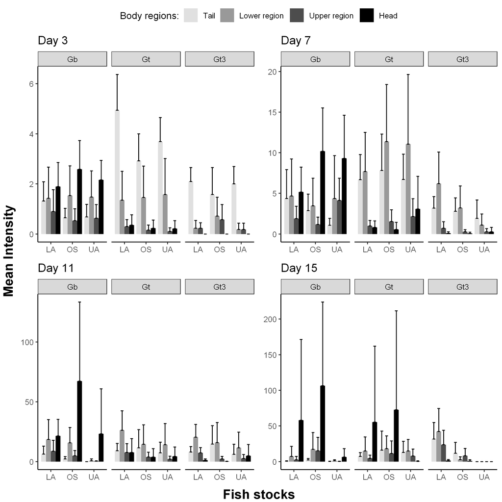

```python
theme_set(
  theme_bw() +
    theme(legend.position = "top")
  )

options(warn=-1)

p=list()
positions <- c("Tail","Lower region","Upper region","Head")
for (i in seq_day){
p[[i]]=ggplot(Means_data[[i]], aes(x=Fish_type, y=Parasite_means, fill=Body_regions)) +
    geom_bar(aes(fill = factor(Body_regions, levels=positions)),position=position_dodge(), stat="identity")+
    labs(fill = "Body regions:",x="Fish stocks",y="Mean Intensity")+
    theme(
  # Hide panel borders and remove grid lines
  panel.border = element_blank(),
  panel.grid.major = element_blank(),
  panel.grid.minor = element_blank(),
  legend.position = "none" , #hide legend
  # Change axis line
  axis.line = element_line(colour = "black"),
        axis.title.x=element_blank(),
        axis.title.y=element_blank()
  )+ ggtitle(paste("Day",i))+facet_wrap( ~ Para_species ) +scale_fill_manual(values=c("grey88","grey60","grey30","grey0"))+
    geom_errorbar(aes(x=Fish_type,ymin=Parasite_means,
                ymax=Parasite_means+1.96*Parasite_stderr,fill = factor(Body_regions, levels=positions)),
                  position=position_dodge(.9),width = 0.5)
}

prow <- plot_grid( p[[3]] + theme(legend.position="none"),
           p[[7]] + theme(legend.position="none"),
           p[[11]] + theme(legend.position="none"),
           p[[15]] + theme(legend.position="none"),
           align = 'vh',
           hjust = -1,
           nrow = 2
           )

p_no_legend <- lapply(p, function(x) x + theme(legend.position = "none"))
legend <- cowplot::get_legend(p[[1]] + theme(legend.position = "top"))


p_grid <- cowplot::plot_grid(plotlist = p_no_legend, ncol = 2)

p <- plot_grid( prow, ncol=1,rel_heights = c(1, .2) )

#create common x and y labels

 y.grob <- textGrob("Mean Intensity",
                   gp=gpar(fontface="bold", col="black", fontsize=15), rot=90)

x.grob <- textGrob("Fish stocks",
                   gp=gpar(fontface="bold", col="black", fontsize=15))



#add to plot

grid.arrange(arrangeGrob(p, top=legend,left = y.grob, bottom = x.grob))
```

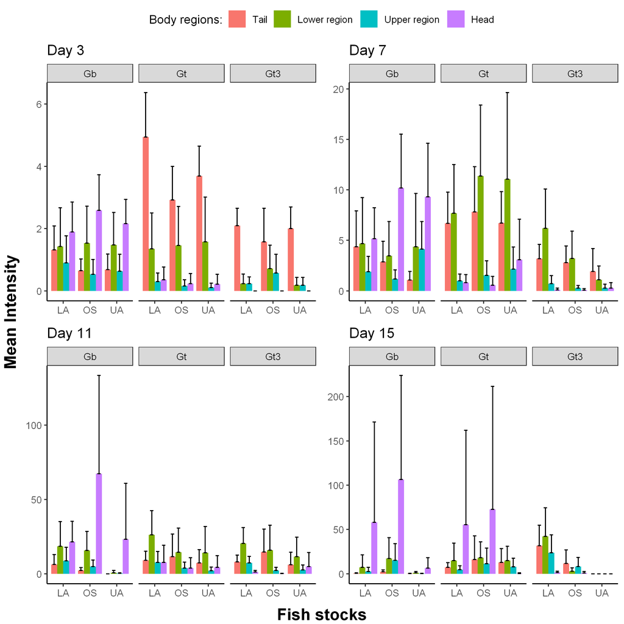

```python
theme_set(
  theme_bw() +
    theme(legend.position = "top")
  )

options(warn=-1)

p=list()
positions <- c("Tail","Lower region","Upper region","Head")
for (i in seq_day){
p[[i]]=ggplot(Means_data[[i]], aes(x=Fish_type, y=Parasite_means, fill=Body_regions)) +
    geom_bar(aes(fill = factor(Body_regions, levels=positions)),position=position_dodge(), stat="identity")+
    labs(fill = "Body regions:",x="Fish stocks",y="Mean Intensity")+ theme(
  # Hide panel borders and remove grid lines
  panel.border = element_blank(),
  panel.grid.major = element_blank(),
  panel.grid.minor = element_blank(),
  legend.position = "none" , #hide legend
  # Change axis line
  axis.line = element_line(colour = "black"),
        axis.title.x=element_blank(),
        axis.title.y=element_blank()
  )+ ggtitle(paste("Day",i))+facet_wrap( ~ Para_species )+
    geom_errorbar(aes(x=Fish_type,ymin=Parasite_means,
                ymax=Parasite_means+1.96*Parasite_stderr,fill = factor(Body_regions, levels=positions)),position=position_dodge(.9),width = 0.5)
}

prow <- plot_grid( p[[3]] + theme(legend.position="none"),
           p[[7]] + theme(legend.position="none"),
           p[[11]] + theme(legend.position="none"),
           p[[15]] + theme(legend.position="none"),
           align = 'vh',
           hjust = -1,
           nrow = 2
           )

p_no_legend <- lapply(p, function(x) x + theme(legend.position = "none"))
legend <- cowplot::get_legend(p[[1]] + theme(legend.position = "top"))


p_grid <- cowplot::plot_grid(plotlist = p_no_legend, ncol = 2)

p <- plot_grid( prow, ncol=1,rel_heights = c(1, .2) )

#create common x and y labels

 y.grob <- textGrob("Mean Intensity",
                   gp=gpar(fontface="bold", col="black", fontsize=15), rot=90)

x.grob <- textGrob("Fish stocks",
                   gp=gpar(fontface="bold", col="black", fontsize=15))



#add to plot

grid.arrange(arrangeGrob(p, top=legend,left = y.grob, bottom = x.grob))
```

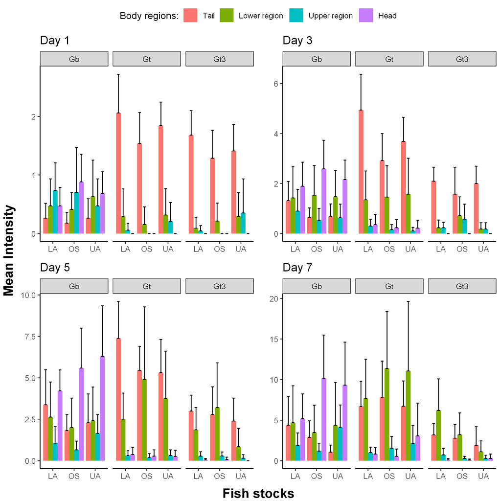

```python
theme_set(
  theme_bw() +
    theme(legend.position = "top")
  )

options(warn=-1)

p=list()
positions <- c("Tail","Lower region","Upper region","Head")
for (i in seq_day){
p[[i]]=ggplot(Means_data[[i]], aes(x=Fish_type, y=Parasite_means, fill=Body_regions)) +
    geom_bar(aes(fill = factor(Body_regions, levels=positions)),position=position_dodge(), stat="identity")+ labs(fill = "Body regions:",x="Fish stocks",y="Mean Intensity")+ theme(
  # Hide panel borders and remove grid lines
  panel.border = element_blank(),
  panel.grid.major = element_blank(),
  panel.grid.minor = element_blank(),
  legend.position = "none" , #hide legend
  # Change axis line
  axis.line = element_line(colour = "black"),
        axis.title.x=element_blank(),
        axis.title.y=element_blank()
  )+ ggtitle(paste("Day",i))+facet_wrap( ~ Para_species )+
    geom_errorbar(aes(x=Fish_type,ymin=Parasite_means,
                ymax=Parasite_means+1.96*Parasite_stderr,fill = factor(Body_regions, levels=positions)),position=position_dodge(.9),width = 0.5)
}

prow <- plot_grid( p[[1]] + theme(legend.position="none"),
           p[[3]] + theme(legend.position="none"),
           p[[5]] + theme(legend.position="none"),
           p[[7]] + theme(legend.position="none"),
           align = 'vh',
           hjust = -1,
           nrow = 2
           )

p_no_legend <- lapply(p, function(x) x + theme(legend.position = "none"))
legend <- cowplot::get_legend(p[[1]] + theme(legend.position = "top"))


p_grid <- cowplot::plot_grid(plotlist = p_no_legend, ncol = 2)

p <- plot_grid( prow, ncol=1,rel_heights = c(1, .2) )

#create common x and y labels

 y.grob <- textGrob("Mean Intensity",
                   gp=gpar(fontface="bold", col="black", fontsize=15), rot=90)

x.grob <- textGrob("Fish stocks",
                   gp=gpar(fontface="bold", col="black", fontsize=15))



#add to plot

grid.arrange(arrangeGrob(p, top=legend,left = y.grob, bottom = x.grob))
```

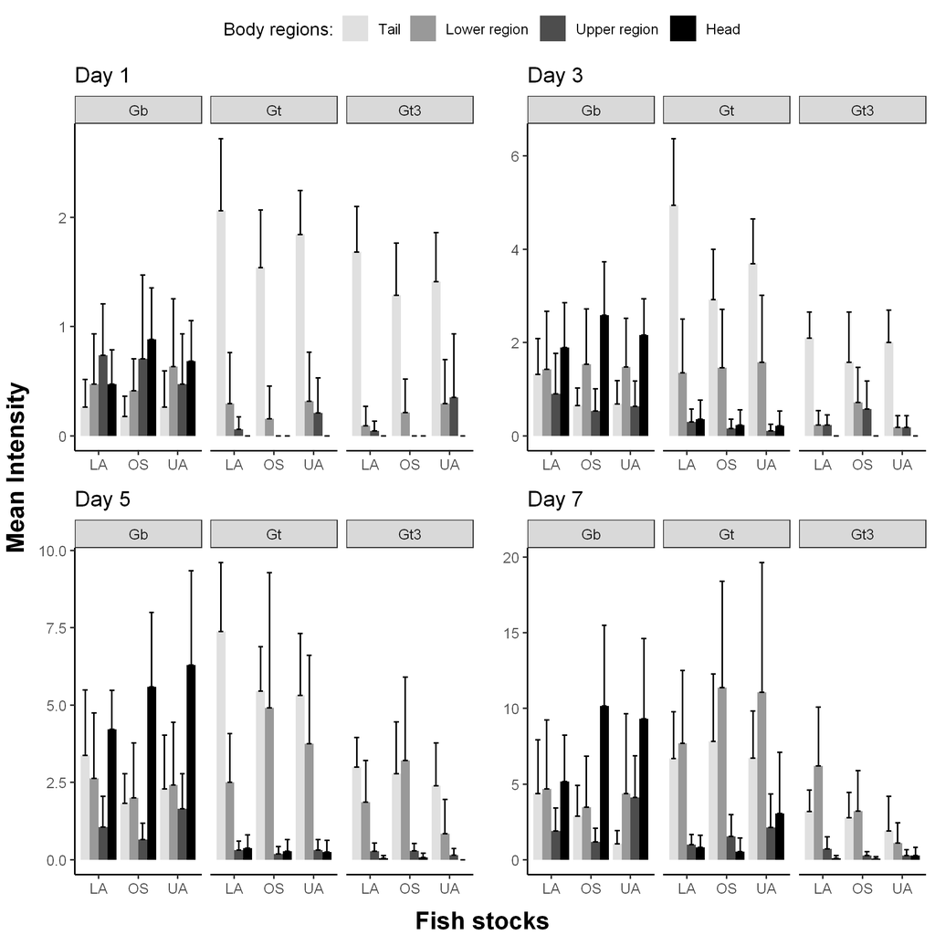

```python
theme_set(
  theme_bw() +
    theme(legend.position = "top")
  )


options(warn=-1)
p=list()
positions <- c("Tail","Lower region","Upper region","Head")
for (i in seq_day){
p[[i]]=ggplot(Means_data[[i]], aes(x=Fish_type, y=Parasite_means, fill=Body_regions)) +
    geom_bar(aes(fill = factor(Body_regions, levels=positions)),position=position_dodge(), stat="identity")+ labs(fill = "Body regions:",x="Fish stocks",y="Mean Intensity")+ theme(
  # Hide panel borders and remove grid lines
  panel.border = element_blank(),
  panel.grid.major = element_blank(),
  panel.grid.minor = element_blank(),
  legend.position = "none" , #hide legend
  # Change axis line
  axis.line = element_line(colour = "black"),
        axis.title.x=element_blank(),
        axis.title.y=element_blank()
  )+ ggtitle(paste("Day",i))+facet_wrap( ~ Para_species )+scale_fill_manual(values=c("grey88","grey60","grey30","grey0"))+
    geom_errorbar(aes(x=Fish_type,ymin=Parasite_means,
                ymax=Parasite_means+1.96*Parasite_stderr,fill = factor(Body_regions, levels=positions)),position=position_dodge(.9),width = 0.5)
}

prow <- plot_grid( p[[1]] + theme(legend.position="none"),
           p[[3]] + theme(legend.position="none"),
           p[[5]] + theme(legend.position="none"),
           p[[7]] + theme(legend.position="none"),
           align = 'vh',
           hjust = -1,
           nrow = 2
           )

p_no_legend <- lapply(p, function(x) x + theme(legend.position = "none"))
legend <- cowplot::get_legend(p[[1]] + theme(legend.position = "top"))


p_grid <- cowplot::plot_grid(plotlist = p_no_legend, ncol = 2)

p <- plot_grid( prow, ncol=1,rel_heights = c(1, .2) )

#create common x and y labels

 y.grob <- textGrob("Mean Intensity",
                   gp=gpar(fontface="bold", col="black", fontsize=15), rot=90)

x.grob <- textGrob("Fish stocks",
                   gp=gpar(fontface="bold", col="black", fontsize=15))



#add to plot

grid.arrange(arrangeGrob(p, top=legend,left = y.grob, bottom = x.grob))
```

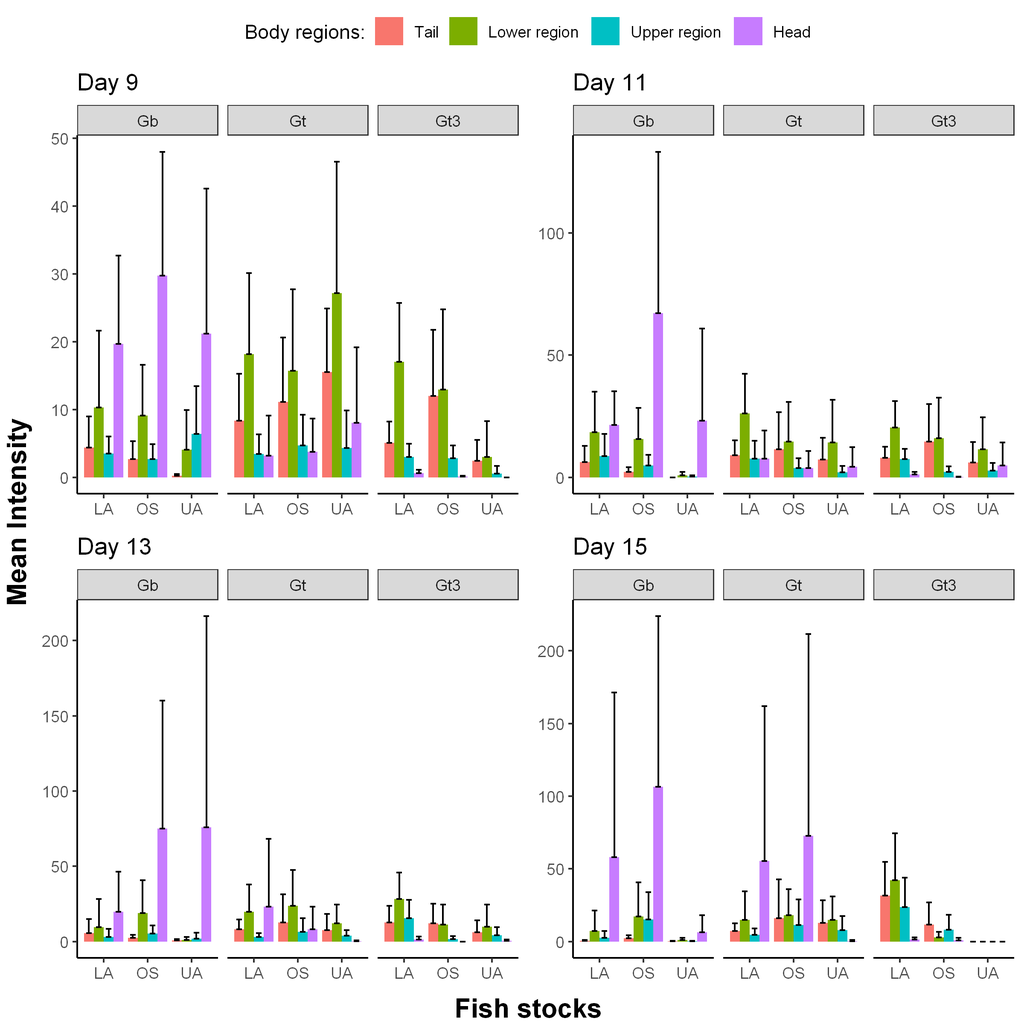

```python
theme_set(
  theme_bw() +
    theme(legend.position = "top")
  )


options(warn=-1)
p=list()
positions <- c("Tail","Lower region","Upper region","Head")
for (i in seq_day){
p[[i]]=ggplot(Means_data[[i]], aes(x=Fish_type, y=Parasite_means, fill=Body_regions)) +
    geom_bar(aes(fill = factor(Body_regions, levels=positions)),position=position_dodge(), stat="identity")+ labs(fill = "Body regions:",x="Fish stocks",y="Mean Intensity")+ theme(
  # Hide panel borders and remove grid lines
  panel.border = element_blank(),
  panel.grid.major = element_blank(),
  panel.grid.minor = element_blank(),
  legend.position = "none" , #hide legend
  # Change axis line
  axis.line = element_line(colour = "black"),
        axis.title.x=element_blank(),
        axis.title.y=element_blank()
  )+ ggtitle(paste("Day",i))+facet_wrap( ~ Para_species )+
    geom_errorbar(aes(x=Fish_type,ymin=Parasite_means,
                ymax=Parasite_means+1.96*Parasite_stderr,fill = factor(Body_regions, levels=positions)),position=position_dodge(.9),width = 0.5)
}

prow <- plot_grid( p[[9]] + theme(legend.position="none"),
           p[[11]] + theme(legend.position="none"),
           p[[13]] + theme(legend.position="none"),
           p[[15]] + theme(legend.position="none"),
           align = 'vh',
           hjust = -1,
           nrow = 2
           )



p_no_legend <- lapply(p, function(x) x + theme(legend.position = "none"))


legend <- cowplot::get_legend(p[[1]] + theme(legend.position = "top"))


p_grid <- cowplot::plot_grid(plotlist = p_no_legend, ncol = 2)

p <- plot_grid( prow, ncol=1,rel_heights = c(1, .2) )

#create common x and y labels

 y.grob <- textGrob("Mean Intensity",
                   gp=gpar(fontface="bold", col="black", fontsize=15), rot=90)

x.grob <- textGrob("Fish stocks",
                   gp=gpar(fontface="bold", col="black", fontsize=15))



#add to plot

grid.arrange(arrangeGrob(p,top=legend,left = y.grob, bottom = x.grob))
```

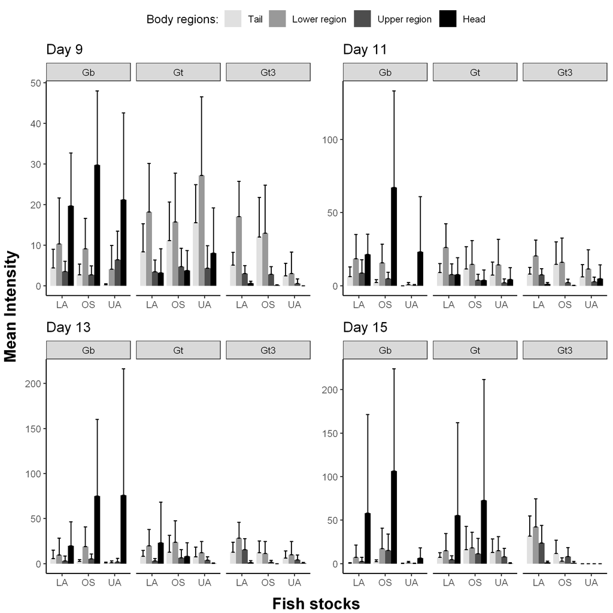

```python
theme_set(
  theme_bw() +
    theme(legend.position = "top")
  )


options(warn=-1)
p=list()
positions <- c("Tail","Lower region","Upper region","Head")
for (i in seq_day){
p[[i]]=ggplot(Means_data[[i]], aes(x=Fish_type, y=Parasite_means, fill=Body_regions)) +
    geom_bar(aes(fill = factor(Body_regions, levels=positions)),position=position_dodge(), stat="identity")+ labs(fill = "Body regions:",x="Fish stocks",y="Mean Intensity")+ theme(
  # Hide panel borders and remove grid lines
  panel.border = element_blank(),
  panel.grid.major = element_blank(),
  panel.grid.minor = element_blank(),
  legend.position = "none" , #hide legend
  # Change axis line
  axis.line = element_line(colour = "black"),
        axis.title.x=element_blank(),
        axis.title.y=element_blank()
  )+ ggtitle(paste("Day",i))+facet_wrap( ~ Para_species )+scale_fill_manual(values=c("grey88","grey60","grey30","grey0"))+
    geom_errorbar(aes(x=Fish_type,ymin=Parasite_means,
                ymax=Parasite_means+1.96*Parasite_stderr,fill = factor(Body_regions, levels=positions)),position=position_dodge(.9),width = 0.5)
}

prow <- plot_grid( p[[9]] + theme(legend.position="none"),
           p[[11]] + theme(legend.position="none"),
           p[[13]] + theme(legend.position="none"),
           p[[15]] + theme(legend.position="none"),
           align = 'vh',
           hjust = -1,
           nrow = 2
           )



p_no_legend <- lapply(p, function(x) x + theme(legend.position = "none"))


legend <- cowplot::get_legend(p[[1]] + theme(legend.position = "top"))


p_grid <- cowplot::plot_grid(plotlist = p_no_legend, ncol = 2)

p <- plot_grid( prow, ncol=1,rel_heights = c(1, .2) )

#create common x and y labels

 y.grob <- textGrob("Mean Intensity",
                   gp=gpar(fontface="bold", col="black", fontsize=15), rot=90)

x.grob <- textGrob("Fish stocks",
                   gp=gpar(fontface="bold", col="black", fontsize=15))



#add to plot

grid.arrange(arrangeGrob(p,top=legend,left = y.grob, bottom = x.grob))
```

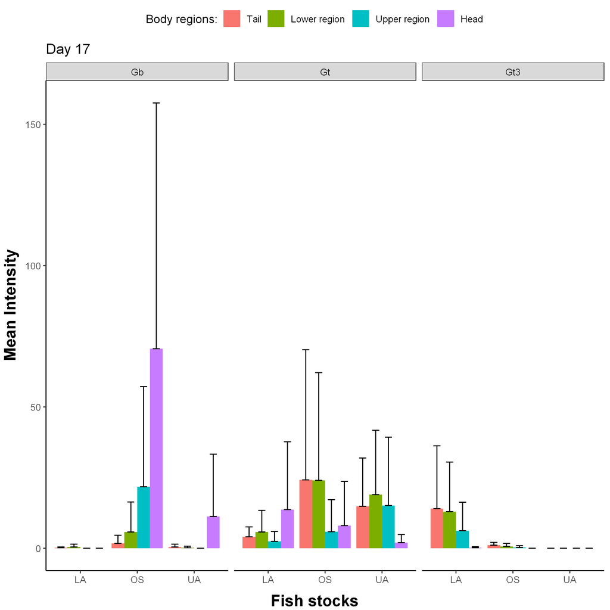

```python
theme_set(
  theme_bw() +
    theme(legend.position = "top")
  )

options(warn=-1)
p=list()
positions <- c("Tail","Lower region","Upper region","Head")
for (i in seq_day){
p[[i]]=ggplot(Means_data[[i]], aes(x=Fish_type, y=Parasite_means, fill=Body_regions)) +
    geom_bar(aes(fill = factor(Body_regions, levels=positions)),position=position_dodge(), stat="identity")+ labs(fill = "Body regions:",x="Fish stocks",y="Mean Intensity")+ theme(
  # Hide panel borders and remove grid lines
  panel.border = element_blank(),
  panel.grid.major = element_blank(),
  panel.grid.minor = element_blank(),
  legend.position = "none" , #hide legend
  # Change axis line
  axis.line = element_line(colour = "black"),
        axis.title.x=element_blank(),
        axis.title.y=element_blank()
  )+ ggtitle(paste("Day",i))+facet_wrap( ~ Para_species )+
    geom_errorbar(aes(x=Fish_type,ymin=Parasite_means,
                ymax=Parasite_means+1.96*Parasite_stderr,fill = factor(Body_regions, levels=positions)),position=position_dodge(.9),width = 0.5)
}

prow <- plot_grid( p[[17]] + theme(legend.position="none"),
           align = 'vh',
           hjust = -1,
           nrow = 1
           )

p_no_legend <- lapply(p, function(x) x + theme(legend.position = "none"))
legend <- cowplot::get_legend(p[[1]] + theme(legend.position = "top"))


p_grid <- cowplot::plot_grid(plotlist = p_no_legend, ncol = 1)

p <- plot_grid( prow, ncol=1,rel_heights = c(1, .2) )

#create common x and y labels

 y.grob <- textGrob("Mean Intensity",
                   gp=gpar(fontface="bold", col="black", fontsize=15), rot=90)

x.grob <- textGrob("Fish stocks",
                   gp=gpar(fontface="bold", col="black", fontsize=15))



#add to plot

grid.arrange(arrangeGrob(p,top=legend, left = y.grob, bottom = x.grob))
```

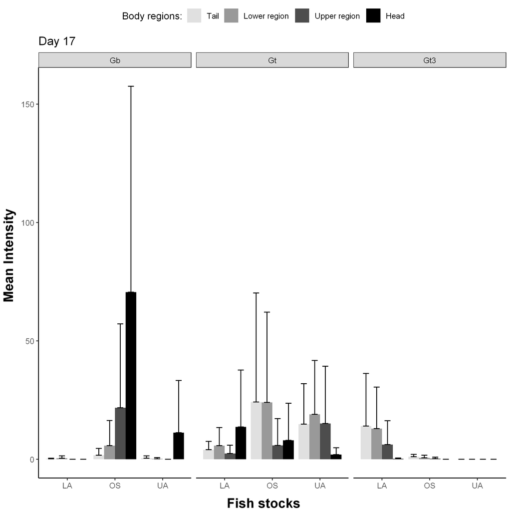

```python
theme_set(
  theme_bw() +
    theme(legend.position = "top")
  )

options(warn=-1)
p=list()
positions <- c("Tail","Lower region","Upper region","Head")
for (i in seq_day){
p[[i]]=ggplot(Means_data[[i]], aes(x=Fish_type, y=Parasite_means, fill=Body_regions)) +
    geom_bar(aes(fill = factor(Body_regions, levels=positions)),position=position_dodge(), stat="identity")+ labs(fill = "Body regions:",x="Fish stocks",y="Mean Intensity")+ theme(
  # Hide panel borders and remove grid lines
  panel.border = element_blank(),
  panel.grid.major = element_blank(),
  panel.grid.minor = element_blank(),
  legend.position = "none" , #hide legend
  # Change axis line
  axis.line = element_line(colour = "black"),
        axis.title.x=element_blank(),
        axis.title.y=element_blank()
  )+ ggtitle(paste("Day",i))+facet_wrap( ~ Para_species ) +scale_fill_manual(values=c("grey88","grey60","grey30","grey0"))+
    geom_errorbar(aes(x=Fish_type,ymin=Parasite_means,
                ymax=Parasite_means+1.96*Parasite_stderr,fill = factor(Body_regions, levels=positions)),position=position_dodge(.9),width = 0.5)
}

prow <- plot_grid( p[[17]] + theme(legend.position="none"),
           align = 'vh',
           hjust = -1,
           nrow = 1
           )

p_no_legend <- lapply(p, function(x) x + theme(legend.position = "none"))
legend <- cowplot::get_legend(p[[1]] + theme(legend.position = "top"))


p_grid <- cowplot::plot_grid(plotlist = p_no_legend, ncol = 1)

p <- plot_grid( prow, ncol=1,rel_heights = c(1, .2) )

#create common x and y labels

 y.grob <- textGrob("Mean Intensity",
                   gp=gpar(fontface="bold", col="black", fontsize=15), rot=90)

x.grob <- textGrob("Fish stocks",
                   gp=gpar(fontface="bold", col="black", fontsize=15))



#add to plot

grid.arrange(arrangeGrob(p,top=legend, left = y.grob, bottom = x.grob))
```

**Extracting Peak times of Infection for each parasite strain across fish stocks**

```python
#Gt3
Gt3_data=split(Means_days,Means_days$Para_species)$"Gt3"
Gt3_OS=split(Gt3_data,Gt3_data$Fish_type)$"OS"
Gt3_LA=split(Gt3_data,Gt3_data$Fish_type)$"LA"
Gt3_UA=split(Gt3_data,Gt3_data$Fish_type)$"UA"
#Gt
Gt_data=split(Means_days,Means_days$Para_species)$"Gt"
Gt_OS=split(Gt_data,Gt_data$Fish_type)$"OS"
Gt_LA=split(Gt_data,Gt_data$Fish_type)$"LA"
Gt_UA=split(Gt_data,Gt_data$Fish_type)$"UA"
#Gb
#Gt
Gb_data=split(Means_days,Means_days$Para_species)$"Gb"
Gb_OS=split(Gb_data,Gb_data$Fish_type)$"OS"
Gb_LA=split(Gb_data,Gb_data$Fish_type)$"LA"
Gb_UA=split(Gb_data,Gb_data$Fish_type)$"UA"



print(paste("Peak time for Gt3-Orn=",Gt3_OS$Day[which.max(Gt3_OS$Parasite_means)]))
print(paste("Peak time for Gt3-LA=",Gt3_LA$Day[which.max(Gt3_LA$Parasite_means)]))
print(paste("Peak time for Gt3-UA=",Gt3_UA$Day[which.max(Gt3_UA$Parasite_means)]))

print(paste("Peak time for Gt-Orn=",Gt_OS$Day[which.max(Gt_OS$Parasite_means)]))
print(paste("Peak time for Gt-LA=",Gt_LA$Day[which.max(Gt_LA$Parasite_means)]))
print(paste("Peak time for Gt-UA=",Gt_UA$Day[which.max(Gt_UA$Parasite_means)]))

print(paste("Peak time for Gb-Orn=",Gb_OS$Day[which.max(Gb_OS$Parasite_means)]))
print(paste("Peak time for Gb-LA=",Gb_LA$Day[which.max(Gb_LA$Parasite_means)]))
print(paste("Peak time for Gb-UA=",Gb_UA$Day[which.max(Gb_UA$Parasite_means)]))
```

```
[1] "Peak time for Gt3-Orn= 11"
[1] "Peak time for Gt3-LA= 15"
[1] "Peak time for Gt3-UA= 11"
[1] "Peak time for Gt-Orn= 15"
[1] "Peak time for Gt-LA= 15"
[1] "Peak time for Gt-UA= 9"
[1] "Peak time for Gb-Orn= 15"
[1] "Peak time for Gb-LA= 15"
[1] "Peak time for Gb-UA= 13"
```

```python
Gt3_OS_Tail=split(Gt3_OS,Gt3_OS$Body_regions)$"Tail"
Gt3_OS_LR=split(Gt3_OS,Gt3_OS$Body_regions)$"Lower region"
Gt3_OS_UR=split(Gt3_OS,Gt3_OS$Body_regions)$"Upper region"
Gt3_OS_Head=split(Gt3_OS,Gt3_OS$Body_regions)$"Head"

print(paste("Peak time for Gt3-Orn at Tail=",Gt3_OS_Tail$Day[which.max(Gt3_OS_Tail$Parasite_means)]))
print(paste("Peak time for Gt3-Orn at Lower region=",Gt3_OS_LR$Day[which.max(Gt3_OS_LR$Parasite_means)]))
print(paste("Peak time for Gt3-Orn at Upper region=",Gt3_OS_UR$Day[which.max(Gt3_OS_UR$Parasite_means)]))
print(paste("Peak time for Gt3-Orn at Head=",Gt3_OS_Head$Day[which.max(Gt3_OS_Head$Parasite_means)]))

Gt3_LA_Tail=split(Gt3_LA,Gt3_LA$Body_regions)$"Tail"
Gt3_LA_LR=split(Gt3_LA,Gt3_LA$Body_regions)$"Lower region"
Gt3_LA_UR=split(Gt3_LA,Gt3_LA$Body_regions)$"Upper region"
Gt3_LA_Head=split(Gt3_LA,Gt3_LA$Body_regions)$"Head"

print(paste("Peak time for Gt3-LA at Tail=",Gt3_LA_Tail$Day[which.max(Gt3_LA_Tail$Parasite_means)]))
print(paste("Peak time for Gt3-LA at Lower region=",Gt3_LA_LR$Day[which.max(Gt3_LA_LR$Parasite_means)]))
print(paste("Peak time for Gt3-LA at Upper region=",Gt3_LA_UR$Day[which.max(Gt3_LA_UR$Parasite_means)]))
print(paste("Peak time for Gt3-LA at Head=",Gt3_LA_Head$Day[which.max(Gt3_LA_Head$Parasite_means)]))



Gt3_UA_Tail=split(Gt3_UA,Gt3_UA$Body_regions)$"Tail"
Gt3_UA_LR=split(Gt3_UA,Gt3_UA$Body_regions)$"Lower region"
Gt3_UA_UR=split(Gt3_UA,Gt3_UA$Body_regions)$"Upper region"
Gt3_UA_Head=split(Gt3_UA,Gt3_UA$Body_regions)$"Head"

print(paste("Peak time for Gt3-UA at Tail=",Gt3_UA_Tail$Day[which.max(Gt3_UA_Tail$Parasite_means)]))
print(paste("Peak time for Gt3-UA at Lower region=",Gt3_UA_LR$Day[which.max(Gt3_UA_LR$Parasite_means)]))
print(paste("Peak time for Gt3-UA at Upper region=",Gt3_UA_UR$Day[which.max(Gt3_UA_UR$Parasite_means)]))
print(paste("Peak time for Gt3-UA at Head=",Gt3_UA_Head$Day[which.max(Gt3_UA_Head$Parasite_means)]))
```

```
[1] "Peak time for Gt3-Orn at Tail= 11"
[1] "Peak time for Gt3-Orn at Lower region= 11"
[1] "Peak time for Gt3-Orn at Upper region= 15"
[1] "Peak time for Gt3-Orn at Head= 15"
[1] "Peak time for Gt3-LA at Tail= 15"
[1] "Peak time for Gt3-LA at Lower region= 15"
[1] "Peak time for Gt3-LA at Upper region= 15"
[1] "Peak time for Gt3-LA at Head= 9"
[1] "Peak time for Gt3-UA at Tail= 11"
[1] "Peak time for Gt3-UA at Lower region= 11"
[1] "Peak time for Gt3-UA at Upper region= 13"
[1] "Peak time for Gt3-UA at Head= 11"
```

```python
Gt_OS_Tail=split(Gt_OS,Gt_OS$Body_regions)$"Tail"
Gt_OS_LR=split(Gt_OS,Gt_OS$Body_regions)$"Lower region"
Gt_OS_UR=split(Gt_OS,Gt_OS$Body_regions)$"Upper region"
Gt_OS_Head=split(Gt_OS,Gt_OS$Body_regions)$"Head"

print(paste("Peak time for Gt-Orn at Tail=",Gt_OS_Tail$Day[which.max(Gt_OS_Tail$Parasite_means)]))
print(paste("Peak time for Gt-Orn at Lower region=",Gt_OS_LR$Day[which.max(Gt_OS_LR$Parasite_means)]))
print(paste("Peak time for Gt-Orn at Upper region=",Gt_OS_UR$Day[which.max(Gt_OS_UR$Parasite_means)]))
print(paste("Peak time for Gt-Orn at Head=",Gt_OS_Head$Day[which.max(Gt_OS_Head$Parasite_means)]))

Gt_LA_Tail=split(Gt_LA,Gt_LA$Body_regions)$"Tail"
Gt_LA_LR=split(Gt_LA,Gt_LA$Body_regions)$"Lower region"
Gt_LA_UR=split(Gt_LA,Gt_LA$Body_regions)$"Upper region"
Gt_LA_Head=split(Gt_LA,Gt_LA$Body_regions)$"Head"

print(paste("Peak time for Gt-LA at Tail=",Gt_LA_Tail$Day[which.max(Gt_LA_Tail$Parasite_means)]))
print(paste("Peak time for Gt-LA at Lower region=",Gt_LA_LR$Day[which.max(Gt_LA_LR$Parasite_means)]))
print(paste("Peak time for Gt-LA at Upper region=",Gt_LA_UR$Day[which.max(Gt_LA_UR$Parasite_means)]))
print(paste("Peak time for Gt-LA at Head=",Gt_LA_Head$Day[which.max(Gt_LA_Head$Parasite_means)]))



Gt_UA_Tail=split(Gt_UA,Gt_UA$Body_regions)$"Tail"
Gt_UA_LR=split(Gt_UA,Gt_UA$Body_regions)$"Lower region"
Gt_UA_UR=split(Gt_UA,Gt_UA$Body_regions)$"Upper region"
Gt_UA_Head=split(Gt_UA,Gt_UA$Body_regions)$"Head"

print(paste("Peak time for Gt-UA at Tail=",Gt_UA_Tail$Day[which.max(Gt_UA_Tail$Parasite_means)]))
print(paste("Peak time for Gt-UA at Lower region=",Gt_UA_LR$Day[which.max(Gt_UA_LR$Parasite_means)]))
print(paste("Peak time for Gt-UA at Upper region=",Gt_UA_UR$Day[which.max(Gt_UA_UR$Parasite_means)]))
print(paste("Peak time for Gt-UA at Head=",Gt_UA_Head$Day[which.max(Gt_UA_Head$Parasite_means)]))
```

```
[1] "Peak time for Gt-Orn at Tail= 17"
[1] "Peak time for Gt-Orn at Lower region= 13"
[1] "Peak time for Gt-Orn at Upper region= 15"
[1] "Peak time for Gt-Orn at Head= 15"
[1] "Peak time for Gt-LA at Tail= 11"
[1] "Peak time for Gt-LA at Lower region= 11"
[1] "Peak time for Gt-LA at Upper region= 11"
[1] "Peak time for Gt-LA at Head= 15"
[1] "Peak time for Gt-UA at Tail= 9"
[1] "Peak time for Gt-UA at Lower region= 9"
[1] "Peak time for Gt-UA at Upper region= 17"
[1] "Peak time for Gt-UA at Head= 9"
```

```python
Gb_OS_Tail=split(Gb_OS,Gb_OS$Body_regions)$"Tail"
Gb_OS_LR=split(Gb_OS,Gb_OS$Body_regions)$"Lower region"
Gb_OS_UR=split(Gb_OS,Gb_OS$Body_regions)$"Upper region"
Gb_OS_Head=split(Gt_OS,Gb_OS$Body_regions)$"Head"

print(paste("Peak time for Gb-Orn at Tail=",Gb_OS_Tail$Day[which.max(Gb_OS_Tail$Parasite_means)]))
print(paste("Peak time for Gb-Orn at Lower region=",Gb_OS_LR$Day[which.max(Gb_OS_LR$Parasite_means)]))
print(paste("Peak time for Gb-Orn at Upper region=",Gb_OS_UR$Day[which.max(Gb_OS_UR$Parasite_means)]))
print(paste("Peak time for Gb-Orn at Head=",Gb_OS_Head$Day[which.max(Gb_OS_Head$Parasite_means)]))

Gb_LA_Tail=split(Gb_LA,Gb_LA$Body_regions)$"Tail"
Gb_LA_LR=split(Gb_LA,Gb_LA$Body_regions)$"Lower region"
Gb_LA_UR=split(Gb_LA,Gb_LA$Body_regions)$"Upper region"
Gb_LA_Head=split(Gb_LA,Gb_LA$Body_regions)$"Head"

print(paste("Peak time for Gb-LA at Tail=",Gb_LA_Tail$Day[which.max(Gb_LA_Tail$Parasite_means)]))
print(paste("Peak time for Gb-LA at Lower region=",Gb_LA_LR$Day[which.max(Gb_LA_LR$Parasite_means)]))
print(paste("Peak time for Gb-LA at Upper region=",Gb_LA_UR$Day[which.max(Gb_LA_UR$Parasite_means)]))
print(paste("Peak time for Gb-LA at Head=",Gb_LA_Head$Day[which.max(Gb_LA_Head$Parasite_means)]))



Gb_UA_Tail=split(Gb_UA,Gb_UA$Body_regions)$"Tail"
Gb_UA_LR=split(Gb_UA,Gb_UA$Body_regions)$"Lower region"
Gb_UA_UR=split(Gb_UA,Gb_UA$Body_regions)$"Upper region"
Gb_UA_Head=split(Gb_UA,Gb_UA$Body_regions)$"Head"

print(paste("Peak time for Gb-UA at Tail=",Gb_UA_Tail$Day[which.max(Gb_UA_Tail$Parasite_means)]))
print(paste("Peak time for Gb-UA at Lower region=",Gb_UA_LR$Day[which.max(Gb_UA_LR$Parasite_means)]))
print(paste("Peak time for Gb-UA at Upper region=",Gb_UA_UR$Day[which.max(Gb_UA_UR$Parasite_means)]))
print(paste("Peak time for Gb-UA at Head=",Gb_UA_Head$Day[which.max(Gb_UA_Head$Parasite_means)]))
```

```
[1] "Peak time for Gb-Orn at Tail= 7"
[1] "Peak time for Gb-Orn at Lower region= 13"
[1] "Peak time for Gb-Orn at Upper region= 17"
[1] "Peak time for Gb-Orn at Head= 15"
[1] "Peak time for Gb-LA at Tail= 11"
[1] "Peak time for Gb-LA at Lower region= 11"
[1] "Peak time for Gb-LA at Upper region= 11"
[1] "Peak time for Gb-LA at Head= 15"
[1] "Peak time for Gb-UA at Tail= 5"
[1] "Peak time for Gb-UA at Lower region= 7"
[1] "Peak time for Gb-UA at Upper region= 9"
[1] "Peak time for Gb-UA at Head= 13"
```

# Statistical tests

Questions to answer:

What is the habitat (body parts) preference of the 3 parasite strain?

How does this vary with fish stocks?

How does this change over time?

NB: The eight different body regions were re-categorized into 4 body regions namely:

1. Tail region,
2. Lower region (made up of the Lower body+ Anal fin+ Pelvic fin+ Dorsal fin),
3. Upper region (made up of Upper body+ Pectoral fin) and
4. Head region.

**Adding variable for the 3 parasite strains and fish stocks to the data**

```python
for (i in seq_day){
MultiData[[i]]$Fish_type=MultiData[[i]]$Group
levels(MultiData[[i]]$Fish_type)=c("Orn","LA","UA","Orn","LA","UA","Orn","LA","UA")

MultiData[[i]]$Parasite_strain=MultiData[[i]]$Group
levels(MultiData[[i]]$Parasite_strain)=c("Gt3","Gt3","Gt3","Gt","Gt","Gt","Gbull","Gbull","Gbull")
    }
```

**Multivariate Kruskal Wallis-Test**

```python
day=seq(1,17,by=2)
MKW_results=list()
 for (i in day)
     {
MKW_results[[i]]=multkw(group=MultiData[[i]][,"Group"],y=MultiData[[i]][,11:14],simplify=F)
     print(MKW_results[[i]])
     }
```

```
  statistic d.f.      p.value
1  131.3364   32 5.428834e-14
  statistic d.f.      p.value
1   165.083   32 7.447248e-20
  statistic d.f.      p.value
1  168.5702   32 1.774237e-20
  statistic d.f.      p.value
1  143.4528   32 4.658675e-16
  statistic d.f.      p.value
1   136.328   32 7.750191e-15
  statistic d.f.      p.value
1  107.2167   32 4.771489e-10
  statistic d.f.     p.value
1  75.87648   32 1.99982e-05
  statistic d.f.      p.value
1  71.24894   32 8.174397e-05
  statistic d.f.   p.value
1  38.12282   32 0.2108254
```

**Univariate Kruskal Wallis test**

```python
#Day 1
day=1
kruskal.test(Tail_region~ Group, data = MultiData[[day]])
kruskal.test(Lower_region~ Group, data = MultiData[[day]])
kruskal.test(Upper_region~Group, data = MultiData[[day]])
kruskal.test(Head_region~ Group, data = MultiData[[day]])
```

```
	Kruskal-Wallis rank sum test

data:  Tail_region by Group
Kruskal-Wallis chi-squared = 71.746, df = 8, p-value = 2.206e-12
```

```
	Kruskal-Wallis rank sum test

data:  Lower_region by Group
Kruskal-Wallis chi-squared = 8.7901, df = 8, p-value = 0.3603
```

```
	Kruskal-Wallis rank sum test

data:  Upper_region by Group
Kruskal-Wallis chi-squared = 18.42, df = 8, p-value = 0.01829
```

```
	Kruskal-Wallis rank sum test

data:  Head_region by Group
Kruskal-Wallis chi-squared = 56.654, df = 8, p-value = 2.103e-09
```

```python
#Day 3
day=3
kruskal.test(Tail_region~Group, data = MultiData[[day]])
kruskal.test(Lower_region~ Group, data = MultiData[[day]])
kruskal.test(Upper_region~Group, data = MultiData[[day]])
kruskal.test(Head_region~ Group, data = MultiData[[day]])
```

```
	Kruskal-Wallis rank sum test

data:  Tail_region by Group
Kruskal-Wallis chi-squared = 51.801, df = 8, p-value = 1.839e-08
```

```
	Kruskal-Wallis rank sum test

data:  Lower_region by Group
Kruskal-Wallis chi-squared = 11.929, df = 8, p-value = 0.1544
```

```
	Kruskal-Wallis rank sum test

data:  Upper_region by Group
Kruskal-Wallis chi-squared = 6.3345, df = 8, p-value = 0.6098
```

```
	Kruskal-Wallis rank sum test

data:  Head_region by Group
Kruskal-Wallis chi-squared = 80.225, df = 8, p-value = 4.405e-14
```

```python
#Day 5
day=5
kruskal.test(Tail_region~ Group, data = MultiData[[day]])
kruskal.test(Lower_region~Group, data = MultiData[[day]])
kruskal.test(Upper_region~ Group, data = MultiData[[day]])
kruskal.test(Head_region~ Group, data = MultiData[[day]])
```

```
	Kruskal-Wallis rank sum test

data:  Tail_region by Group
Kruskal-Wallis chi-squared = 35.072, df = 8, p-value = 2.594e-05
```

```
	Kruskal-Wallis rank sum test

data:  Lower_region by Group
Kruskal-Wallis chi-squared = 6.6957, df = 8, p-value = 0.5698
```

```
	Kruskal-Wallis rank sum test

data:  Upper_region by Group
Kruskal-Wallis chi-squared = 11.875, df = 8, p-value = 0.1569
```

```
	Kruskal-Wallis rank sum test

data:  Head_region by Group
Kruskal-Wallis chi-squared = 83.387, df = 8, p-value = 1.015e-14
```

```python
#Day 7
day=7
kruskal.test(Tail_region~ Group, data = MultiData[[day]])
kruskal.test(Lower_region~ Group, data = MultiData[[day]])
kruskal.test(Upper_region~Group, data = MultiData[[day]])
kruskal.test(Head_region~ Group, data = MultiData[[day]])
```

```
	Kruskal-Wallis rank sum test

data:  Tail_region by Group
Kruskal-Wallis chi-squared = 24.927, df = 8, p-value = 0.001599
```

```
	Kruskal-Wallis rank sum test

data:  Lower_region by Group
Kruskal-Wallis chi-squared = 17.738, df = 8, p-value = 0.02328
```

```
	Kruskal-Wallis rank sum test

data:  Upper_region by Group
Kruskal-Wallis chi-squared = 12.182, df = 8, p-value = 0.1433
```

```
	Kruskal-Wallis rank sum test

data:  Head_region by Group
Kruskal-Wallis chi-squared = 47.356, df = 8, p-value = 1.312e-07
```

```python
#Day 9
day=9
kruskal.test(Tail_region~ Group, data = MultiData[[day]])
kruskal.test(Lower_region~ Group, data = MultiData[[day]])
kruskal.test(Upper_region~ Group, data = MultiData[[day]])
kruskal.test(Head_region~ Group, data = MultiData[[day]])
```

```
	Kruskal-Wallis rank sum test

data:  Tail_region by Group
Kruskal-Wallis chi-squared = 25.879, df = 8, p-value = 0.001101
```

```
	Kruskal-Wallis rank sum test

data:  Lower_region by Group
Kruskal-Wallis chi-squared = 18.218, df = 8, p-value = 0.01965
```

```
	Kruskal-Wallis rank sum test

data:  Upper_region by Group
Kruskal-Wallis chi-squared = 4.5349, df = 8, p-value = 0.8059
```

```
	Kruskal-Wallis rank sum test

data:  Head_region by Group
Kruskal-Wallis chi-squared = 32.642, df = 8, p-value = 7.145e-05
```

```python
#Day 11
day=11
kruskal.test(Tail_region~ Group, data = MultiData[[day]])
kruskal.test(Lower_region~ Group, data = MultiData[[day]])
kruskal.test(Upper_region~ Group, data = MultiData[[day]])
kruskal.test(Head_region~ Group, data = MultiData[[day]])
```

```
	Kruskal-Wallis rank sum test

data:  Tail_region by Group
Kruskal-Wallis chi-squared = 15.072, df = 8, p-value = 0.05776
```

```
	Kruskal-Wallis rank sum test

data:  Lower_region by Group
Kruskal-Wallis chi-squared = 17.118, df = 8, p-value = 0.02891
```

```
	Kruskal-Wallis rank sum test

data:  Upper_region by Group
Kruskal-Wallis chi-squared = 11.998, df = 8, p-value = 0.1513
```

```
	Kruskal-Wallis rank sum test

data:  Head_region by Group
Kruskal-Wallis chi-squared = 27.009, df = 8, p-value = 0.0007043
```

```python
#Day 13
day=13
kruskal.test(Tail_region~ Group, data = MultiData[[day]])
kruskal.test(Lower_region~ Group, data = MultiData[[day]])
kruskal.test(Upper_region~ Group, data = MultiData[[day]])
kruskal.test(Head_region~Group, data = MultiData[[day]])
```

```
	Kruskal-Wallis rank sum test

data:  Tail_region by Group
Kruskal-Wallis chi-squared = 10.516, df = 8, p-value = 0.2307
```

```
	Kruskal-Wallis rank sum test

data:  Lower_region by Group
Kruskal-Wallis chi-squared = 12.056, df = 8, p-value = 0.1487
```

```
	Kruskal-Wallis rank sum test

data:  Upper_region by Group
Kruskal-Wallis chi-squared = 6.6728, df = 8, p-value = 0.5723
```

```
	Kruskal-Wallis rank sum test

data:  Head_region by Group
Kruskal-Wallis chi-squared = 21.221, df = 8, p-value = 0.006583
```

```python
#Day 15
day=15
kruskal.test(Tail_region~ Group, data = MultiData[[day]])
kruskal.test(Lower_region~ Group, data = MultiData[[day]])
kruskal.test(Upper_region~ Group, data = MultiData[[day]])
kruskal.test(Head_region~ Group, data = MultiData[[day]])
```

```
	Kruskal-Wallis rank sum test

data:  Tail_region by Group
Kruskal-Wallis chi-squared = 19.491, df = 8, p-value = 0.01245
```

```
	Kruskal-Wallis rank sum test

data:  Lower_region by Group
Kruskal-Wallis chi-squared = 11.801, df = 8, p-value = 0.1603
```

```
	Kruskal-Wallis rank sum test

data:  Upper_region by Group
Kruskal-Wallis chi-squared = 12.039, df = 8, p-value = 0.1495
```

```
	Kruskal-Wallis rank sum test

data:  Head_region by Group
Kruskal-Wallis chi-squared = 10.22, df = 8, p-value = 0.2499
```

```python
#Day 17
day=17
kruskal.test(Tail_region~ Group, data = MultiData[[day]])
kruskal.test(Lower_region~ Group, data = MultiData[[day]])
kruskal.test(Upper_region~ Group, data = MultiData[[day]])
kruskal.test(Head_region~ Group, data = MultiData[[day]])
```

```
	Kruskal-Wallis rank sum test

data:  Tail_region by Group
Kruskal-Wallis chi-squared = 10.394, df = 8, p-value = 0.2385
```

```
	Kruskal-Wallis rank sum test

data:  Lower_region by Group
Kruskal-Wallis chi-squared = 8.1161, df = 8, p-value = 0.4222
```

```
	Kruskal-Wallis rank sum test

data:  Upper_region by Group
Kruskal-Wallis chi-squared = 10.316, df = 8, p-value = 0.2435
```

```
	Kruskal-Wallis rank sum test

data:  Head_region by Group
Kruskal-Wallis chi-squared = 7.912, df = 8, p-value = 0.4421
```

**The Pairwise Multiple Comparison of Mean Ranks (PMCMR) using Multiple Bonferroni-Dunn's test**

```python
library(PMCMRplus)
```

```python
day=1
posthoc.kruskal.dunn.test(x=MultiData[[day]]$Tail_region, g=MultiData[[day]]$Group, p.adjust.method="bonferroni")
posthoc.kruskal.dunn.test(x=MultiData[[day]]$Lower_region, g=MultiData[[day]]$Group, p.adjust.method="bonferroni")
posthoc.kruskal.dunn.test(x=MultiData[[day]]$Upper_region, g=MultiData[[day]]$Group, p.adjust.method="bonferroni")
posthoc.kruskal.dunn.test(x=MultiData[[day]]$Head_region, g=MultiData[[day]]$Group, p.adjust.method="bonferroni")
```

```
	Pairwise comparisons using Dunn's-test for multiple
                         comparisons of independent samples

data:  MultiData[[day]]$Tail_region and MultiData[[day]]$Group

       Gt3-Orn Gt3-LA  Gt3-UA  Gt-Orn  Gt-LA   Gt-UA   Gb-Orn  Gb-LA
Gt3-LA 1.00000 -       -       -       -       -       -       -
Gt3-UA 1.00000 1.00000 -       -       -       -       -       -
Gt-Orn 1.00000 1.00000 1.00000 -       -       -       -       -
Gt-LA  1.00000 1.00000 1.00000 1.00000 -       -       -       -
Gt-UA  1.00000 1.00000 1.00000 1.00000 1.00000 -       -       -
Gb-Orn 0.05280 0.00018 0.00873 0.00749 7.7e-05 3.7e-05 -       -
Gb-LA  0.09394 0.00035 0.01628 0.01372 0.00015 7.1e-05 1.00000 -
Gb-UA  0.06817 0.00021 0.01107 0.00956 8.9e-05 4.2e-05 1.00000 1.00000

P value adjustment method: bonferroni
```

```
	Pairwise comparisons using Dunn's-test for multiple
                         comparisons of independent samples

data:  MultiData[[day]]$Lower_region and MultiData[[day]]$Group

       Gt3-Orn Gt3-LA Gt3-UA Gt-Orn Gt-LA Gt-UA Gb-Orn Gb-LA
Gt3-LA 1.00    -      -      -      -     -     -      -
Gt3-UA 1.00    1.00   -      -      -     -     -      -
Gt-Orn 1.00    1.00   1.00   -      -     -     -      -
Gt-LA  1.00    1.00   1.00   1.00   -     -     -      -
Gt-UA  1.00    1.00   1.00   1.00   1.00  -     -      -
Gb-Orn 1.00    0.68   1.00   1.00   1.00  1.00  -      -
Gb-LA  1.00    1.00   1.00   1.00   1.00  1.00  1.00   -
Gb-UA  1.00    1.00   1.00   1.00   1.00  1.00  1.00   1.00

P value adjustment method: bonferroni
```

```
	Pairwise comparisons using Dunn's-test for multiple
                         comparisons of independent samples

data:  MultiData[[day]]$Upper_region and MultiData[[day]]$Group

       Gt3-Orn Gt3-LA Gt3-UA Gt-Orn Gt-LA Gt-UA Gb-Orn Gb-LA
Gt3-LA 1.000   -      -      -      -     -     -      -
Gt3-UA 1.000   1.000  -      -      -     -     -      -
Gt-Orn 1.000   1.000  1.000  -      -     -     -      -
Gt-LA  1.000   1.000  1.000  1.000  -     -     -      -
Gt-UA  1.000   1.000  1.000  1.000  1.000 -     -      -
Gb-Orn 1.000   1.000  1.000  1.000  1.000 1.000 -      -
Gb-LA  0.083   0.085  1.000  0.103  0.216 0.644 1.000  -
Gb-UA  1.000   1.000  1.000  1.000  1.000 1.000 1.000  1.000

P value adjustment method: bonferroni
```

```
	Pairwise comparisons using Dunn's-test for multiple
                         comparisons of independent samples

data:  MultiData[[day]]$Head_region and MultiData[[day]]$Group

       Gt3-Orn Gt3-LA  Gt3-UA  Gt-Orn  Gt-LA   Gt-UA   Gb-Orn  Gb-LA
Gt3-LA 1.00000 -       -       -       -       -       -       -
Gt3-UA 1.00000 1.00000 -       -       -       -       -       -
Gt-Orn 1.00000 1.00000 1.00000 -       -       -       -       -
Gt-LA  1.00000 1.00000 1.00000 1.00000 -       -       -       -
Gt-UA  1.00000 1.00000 1.00000 1.00000 1.00000 -       -       -
Gb-Orn 0.00168 0.00019 0.00066 0.00240 0.00066 0.00039 -       -
Gb-LA  0.20564 0.06773 0.12765 0.24618 0.12765 0.09703 1.00000 -
Gb-UA  0.00974 0.00151 0.00438 0.01315 0.00438 0.00277 1.00000 1.00000

P value adjustment method: bonferroni
```

```python
day=3
posthoc.kruskal.dunn.test(x=MultiData[[day]]$Tail_region, g=MultiData[[day]]$Group, p.adjust.method="bonferroni")
posthoc.kruskal.dunn.test(x=MultiData[[day]]$Lower_region, g=MultiData[[day]]$Group, p.adjust.method="bonferroni")
posthoc.kruskal.dunn.test(x=MultiData[[day]]$Upper_region, g=MultiData[[day]]$Group, p.adjust.method="bonferroni")
posthoc.kruskal.dunn.test(x=MultiData[[day]]$Head_region, g=MultiData[[day]]$Group, p.adjust.method="bonferroni")
```

```
	Pairwise comparisons using Dunn's-test for multiple
                         comparisons of independent samples

data:  MultiData[[day]]$Tail_region and MultiData[[day]]$Group

       Gt3-Orn Gt3-LA  Gt3-UA  Gt-Orn  Gt-LA   Gt-UA   Gb-Orn  Gb-LA
Gt3-LA 1.00000 -       -       -       -       -       -       -
Gt3-UA 1.00000 1.00000 -       -       -       -       -       -
Gt-Orn 1.00000 1.00000 1.00000 -       -       -       -       -
Gt-LA  0.01856 0.45228 0.36118 1.00000 -       -       -       -
Gt-UA  0.14279 1.00000 1.00000 1.00000 1.00000 -       -       -
Gb-Orn 1.00000 0.24390 0.72384 0.05689 3.5e-05 0.00056 -       -
Gb-LA  1.00000 1.00000 1.00000 0.82636 0.00230 0.02619 1.00000 -
Gb-UA  1.00000 0.15411 0.51592 0.03600 1.3e-05 0.00024 1.00000 1.00000

P value adjustment method: bonferroni
```

```
	Pairwise comparisons using Dunn's-test for multiple
                         comparisons of independent samples

data:  MultiData[[day]]$Lower_region and MultiData[[day]]$Group

       Gt3-Orn Gt3-LA Gt3-UA Gt-Orn Gt-LA Gt-UA Gb-Orn Gb-LA
Gt3-LA 1.00    -      -      -      -     -     -      -
Gt3-UA 1.00    1.00   -      -      -     -     -      -
Gt-Orn 1.00    1.00   1.00   -      -     -     -      -
Gt-LA  1.00    1.00   1.00   1.00   -     -     -      -
Gt-UA  1.00    1.00   1.00   1.00   1.00  -     -      -
Gb-Orn 1.00    1.00   1.00   1.00   1.00  1.00  -      -
Gb-LA  1.00    1.00   1.00   1.00   1.00  1.00  1.00   -
Gb-UA  1.00    0.43   0.78   1.00   1.00  1.00  1.00   1.00

P value adjustment method: bonferroni
```

```
	Pairwise comparisons using Dunn's-test for multiple
                         comparisons of independent samples

data:  MultiData[[day]]$Upper_region and MultiData[[day]]$Group

       Gt3-Orn Gt3-LA Gt3-UA Gt-Orn Gt-LA Gt-UA Gb-Orn Gb-LA
Gt3-LA 1       -      -      -      -     -     -      -
Gt3-UA 1       1      -      -      -     -     -      -
Gt-Orn 1       1      1      -      -     -     -      -
Gt-LA  1       1      1      1      -     -     -      -
Gt-UA  1       1      1      1      1     -     -      -
Gb-Orn 1       1      1      1      1     1     -      -
Gb-LA  1       1      1      1      1     1     1      -
Gb-UA  1       1      1      1      1     1     1      1

P value adjustment method: bonferroni
```

```
	Pairwise comparisons using Dunn's-test for multiple
                         comparisons of independent samples

data:  MultiData[[day]]$Head_region and MultiData[[day]]$Group

       Gt3-Orn Gt3-LA  Gt3-UA  Gt-Orn  Gt-LA   Gt-UA   Gb-Orn  Gb-LA
Gt3-LA 1.00000 -       -       -       -       -       -       -
Gt3-UA 1.00000 1.00000 -       -       -       -       -       -
Gt-Orn 1.00000 1.00000 1.00000 -       -       -       -       -
Gt-LA  1.00000 1.00000 1.00000 1.00000 -       -       -       -
Gt-UA  1.00000 1.00000 1.00000 1.00000 1.00000 -       -       -
Gb-Orn 8.5e-05 4.8e-06 2.4e-05 0.00412 0.00286 0.00027 -       -
Gb-LA  0.00188 0.00019 0.00071 0.05409 0.04625 0.00630 1.00000 -
Gb-UA  5.8e-05 2.5e-06 1.5e-05 0.00332 0.00216 0.00018 1.00000 1.00000

P value adjustment method: bonferroni
```

```python
day=5
posthoc.kruskal.dunn.test(x=MultiData[[day]]$Tail_region, g=MultiData[[day]]$Group, p.adjust.method="bonferroni")
posthoc.kruskal.dunn.test(x=MultiData[[day]]$Lower_region, g=MultiData[[day]]$Group, p.adjust.method="bonferroni")
posthoc.kruskal.dunn.test(x=MultiData[[day]]$Upper_region, g=MultiData[[day]]$Group, p.adjust.method="bonferroni")
posthoc.kruskal.dunn.test(x=MultiData[[day]]$Head_region, g=MultiData[[day]]$Group, p.adjust.method="bonferroni")
```

```
	Pairwise comparisons using Dunn's-test for multiple
                         comparisons of independent samples

data:  MultiData[[day]]$Tail_region and MultiData[[day]]$Group

       Gt3-Orn Gt3-LA Gt3-UA Gt-Orn Gt-LA  Gt-UA  Gb-Orn Gb-LA
Gt3-LA 1.0000  -      -      -      -      -      -      -
Gt3-UA 1.0000  1.0000 -      -      -      -      -      -
Gt-Orn 0.4403  0.9269 0.2614 -      -      -      -      -
Gt-LA  0.0521  0.1033 0.0277 1.0000 -      -      -      -
Gt-UA  1.0000  1.0000 1.0000 1.0000 1.0000 -      -      -
Gb-Orn 1.0000  1.0000 1.0000 0.0330 0.0013 0.1884 -      -
Gb-LA  1.0000  1.0000 1.0000 0.4180 0.0376 1.0000 1.0000 -
Gb-UA  1.0000  1.0000 1.0000 0.0414 0.0018 0.2341 1.0000 1.0000

P value adjustment method: bonferroni
```

```
	Pairwise comparisons using Dunn's-test for multiple
                         comparisons of independent samples

data:  MultiData[[day]]$Lower_region and MultiData[[day]]$Group

       Gt3-Orn Gt3-LA Gt3-UA Gt-Orn Gt-LA Gt-UA Gb-Orn Gb-LA
Gt3-LA 1       -      -      -      -     -     -      -
Gt3-UA 1       1      -      -      -     -     -      -
Gt-Orn 1       1      1      -      -     -     -      -
Gt-LA  1       1      1      1      -     -     -      -
Gt-UA  1       1      1      1      1     -     -      -
Gb-Orn 1       1      1      1      1     1     -      -
Gb-LA  1       1      1      1      1     1     1      -
Gb-UA  1       1      1      1      1     1     1      1

P value adjustment method: bonferroni
```

```
	Pairwise comparisons using Dunn's-test for multiple
                         comparisons of independent samples

data:  MultiData[[day]]$Upper_region and MultiData[[day]]$Group

       Gt3-Orn Gt3-LA Gt3-UA Gt-Orn Gt-LA Gt-UA Gb-Orn Gb-LA
Gt3-LA 1.00    -      -      -      -     -     -      -
Gt3-UA 1.00    1.00   -      -      -     -     -      -
Gt-Orn 1.00    1.00   1.00   -      -     -     -      -
Gt-LA  1.00    1.00   1.00   1.00   -     -     -      -
Gt-UA  1.00    1.00   1.00   1.00   1.00  -     -      -
Gb-Orn 1.00    1.00   1.00   1.00   1.00  1.00  -      -
Gb-LA  1.00    1.00   1.00   1.00   1.00  1.00  1.00   -
Gb-UA  1.00    0.33   0.39   0.80   1.00  0.70  1.00   1.00

P value adjustment method: bonferroni
```

```
	Pairwise comparisons using Dunn's-test for multiple
                         comparisons of independent samples

data:  MultiData[[day]]$Head_region and MultiData[[day]]$Group

       Gt3-Orn Gt3-LA  Gt3-UA  Gt-Orn  Gt-LA   Gt-UA   Gb-Orn  Gb-LA
Gt3-LA 1.00000 -       -       -       -       -       -       -
Gt3-UA 1.00000 1.00000 -       -       -       -       -       -
Gt-Orn 1.00000 1.00000 1.00000 -       -       -       -       -
Gt-LA  1.00000 1.00000 1.00000 1.00000 -       -       -       -
Gt-UA  1.00000 1.00000 1.00000 1.00000 1.00000 -       -       -
Gb-Orn 0.00045 2.1e-05 0.00019 0.01049 0.00278 0.00079 -       -
Gb-LA  8.1e-05 2.0e-06 3.4e-05 0.00300 0.00056 0.00014 1.00000 -
Gb-UA  0.00036 1.6e-05 0.00016 0.00890 0.00228 0.00064 1.00000 1.00000

P value adjustment method: bonferroni
```

```python
day=7
posthoc.kruskal.dunn.test(x=MultiData[[day]]$Tail_region, g=MultiData[[day]]$Group, p.adjust.method="bonferroni")
posthoc.kruskal.dunn.test(x=MultiData[[day]]$Lower_region, g=MultiData[[day]]$Group, p.adjust.method="bonferroni")
posthoc.kruskal.dunn.test(x=MultiData[[day]]$Upper_region, g=MultiData[[day]]$Group, p.adjust.method="bonferroni")
posthoc.kruskal.dunn.test(x=MultiData[[day]]$Head_region, g=MultiData[[day]]$Group, p.adjust.method="bonferroni")
```

```
	Pairwise comparisons using Dunn's-test for multiple
                         comparisons of independent samples

data:  MultiData[[day]]$Tail_region and MultiData[[day]]$Group

       Gt3-Orn Gt3-LA Gt3-UA Gt-Orn Gt-LA Gt-UA Gb-Orn Gb-LA
Gt3-LA 1.000   -      -      -      -     -     -      -
Gt3-UA 1.000   1.000  -      -      -     -     -      -
Gt-Orn 1.000   1.000  0.102  -      -     -     -      -
Gt-LA  1.000   1.000  0.127  1.000  -     -     -      -
Gt-UA  1.000   1.000  0.175  1.000  1.000 -     -      -
Gb-Orn 1.000   1.000  1.000  0.817  1.000 1.000 -      -
Gb-LA  1.000   1.000  1.000  1.000  1.000 1.000 1.000  -
Gb-UA  1.000   1.000  1.000  0.036  0.037 0.060 1.000  1.000

P value adjustment method: bonferroni
```

```
	Pairwise comparisons using Dunn's-test for multiple
                         comparisons of independent samples

data:  MultiData[[day]]$Lower_region and MultiData[[day]]$Group

       Gt3-Orn Gt3-LA Gt3-UA Gt-Orn Gt-LA Gt-UA Gb-Orn Gb-LA
Gt3-LA 1.000   -      -      -      -     -     -      -
Gt3-UA 1.000   1.000  -      -      -     -     -      -
Gt-Orn 0.597   1.000  0.039  -      -     -     -      -
Gt-LA  1.000   1.000  1.000  1.000  -     -     -      -
Gt-UA  1.000   1.000  0.375  1.000  1.000 -     -      -
Gb-Orn 1.000   1.000  1.000  0.090  1.000 0.895 -      -
Gb-LA  1.000   1.000  1.000  1.000  1.000 1.000 1.000  -
Gb-UA  1.000   1.000  1.000  0.273  1.000 1.000 1.000  1.000

P value adjustment method: bonferroni
```

```
	Pairwise comparisons using Dunn's-test for multiple
                         comparisons of independent samples

data:  MultiData[[day]]$Upper_region and MultiData[[day]]$Group

       Gt3-Orn Gt3-LA Gt3-UA Gt-Orn Gt-LA Gt-UA Gb-Orn Gb-LA
Gt3-LA 1.00    -      -      -      -     -     -      -
Gt3-UA 1.00    1.00   -      -      -     -     -      -
Gt-Orn 1.00    1.00   1.00   -      -     -     -      -
Gt-LA  1.00    1.00   1.00   1.00   -     -     -      -
Gt-UA  1.00    1.00   1.00   1.00   1.00  -     -      -
Gb-Orn 1.00    1.00   1.00   1.00   1.00  1.00  -      -
Gb-LA  1.00    1.00   1.00   1.00   1.00  1.00  1.00   -
Gb-UA  0.65    0.27   0.43   1.00   1.00  1.00  1.00   1.00

P value adjustment method: bonferroni
```

```
	Pairwise comparisons using Dunn's-test for multiple
                         comparisons of independent samples

data:  MultiData[[day]]$Head_region and MultiData[[day]]$Group

       Gt3-Orn Gt3-LA  Gt3-UA  Gt-Orn  Gt-LA   Gt-UA   Gb-Orn  Gb-LA
Gt3-LA 1.00000 -       -       -       -       -       -       -
Gt3-UA 1.00000 1.00000 -       -       -       -       -       -
Gt-Orn 1.00000 1.00000 1.00000 -       -       -       -       -
Gt-LA  1.00000 1.00000 1.00000 1.00000 -       -       -       -
Gt-UA  1.00000 1.00000 1.00000 1.00000 1.00000 -       -       -
Gb-Orn 0.00052 3.8e-05 0.00325 0.01560 0.01338 0.50038 -       -
Gb-LA  0.03670 0.00669 0.12545 0.42681 0.51335 1.00000 1.00000 -
Gb-UA  0.03302 0.00676 0.10762 0.35869 0.43425 1.00000 1.00000 1.00000

P value adjustment method: bonferroni
```

```python
day=9
posthoc.kruskal.dunn.test(x=MultiData[[day]]$Tail_region, g=MultiData[[day]]$Group, p.adjust.method="bonferroni")
posthoc.kruskal.dunn.test(x=MultiData[[day]]$Lower_region, g=MultiData[[day]]$Group, p.adjust.method="bonferroni")
posthoc.kruskal.dunn.test(x=MultiData[[day]]$Upper_region, g=MultiData[[day]]$Group, p.adjust.method="bonferroni")
posthoc.kruskal.dunn.test(x=MultiData[[day]]$Head_region, g=MultiData[[day]]$Group, p.adjust.method="bonferroni")
```

```
	Pairwise comparisons using Dunn's-test for multiple
                         comparisons of independent samples

data:  MultiData[[day]]$Tail_region and MultiData[[day]]$Group

       Gt3-Orn Gt3-LA Gt3-UA Gt-Orn Gt-LA  Gt-UA  Gb-Orn Gb-LA
Gt3-LA 1.0000  -      -      -      -      -      -      -
Gt3-UA 1.0000  1.0000 -      -      -      -      -      -
Gt-Orn 1.0000  1.0000 1.0000 -      -      -      -      -
Gt-LA  1.0000  1.0000 1.0000 1.0000 -      -      -      -
Gt-UA  1.0000  1.0000 0.3914 1.0000 1.0000 -      -      -
Gb-Orn 1.0000  1.0000 1.0000 1.0000 0.9673 0.1906 -      -
Gb-LA  1.0000  1.0000 1.0000 1.0000 1.0000 0.3078 1.0000 -
Gb-UA  0.2500  0.4167 1.0000 0.0626 0.0268 0.0038 1.0000 1.0000

P value adjustment method: bonferroni
```

```
	Pairwise comparisons using Dunn's-test for multiple
                         comparisons of independent samples

data:  MultiData[[day]]$Lower_region and MultiData[[day]]$Group

       Gt3-Orn Gt3-LA Gt3-UA Gt-Orn Gt-LA Gt-UA Gb-Orn Gb-LA
Gt3-LA 1.00    -      -      -      -     -     -      -
Gt3-UA 1.00    0.48   -      -      -     -     -      -
Gt-Orn 1.00    1.00   0.90   -      -     -     -      -
Gt-LA  1.00    1.00   0.96   1.00   -     -     -      -
Gt-UA  1.00    1.00   0.39   1.00   1.00  -     -      -
Gb-Orn 1.00    1.00   1.00   1.00   1.00  1.00  -      -
Gb-LA  1.00    1.00   1.00   1.00   1.00  1.00  1.00   -
Gb-UA  1.00    0.30   1.00   0.77   0.78  0.28  1.00   1.00

P value adjustment method: bonferroni
```

```
	Pairwise comparisons using Dunn's-test for multiple
                         comparisons of independent samples

data:  MultiData[[day]]$Upper_region and MultiData[[day]]$Group

       Gt3-Orn Gt3-LA Gt3-UA Gt-Orn Gt-LA Gt-UA Gb-Orn Gb-LA
Gt3-LA 1       -      -      -      -     -     -      -
Gt3-UA 1       1      -      -      -     -     -      -
Gt-Orn 1       1      1      -      -     -     -      -
Gt-LA  1       1      1      1      -     -     -      -
Gt-UA  1       1      1      1      1     -     -      -
Gb-Orn 1       1      1      1      1     1     -      -
Gb-LA  1       1      1      1      1     1     1      -
Gb-UA  1       1      1      1      1     1     1      1

P value adjustment method: bonferroni
```

```
	Pairwise comparisons using Dunn's-test for multiple
                         comparisons of independent samples

data:  MultiData[[day]]$Head_region and MultiData[[day]]$Group

       Gt3-Orn Gt3-LA Gt3-UA Gt-Orn Gt-LA  Gt-UA  Gb-Orn Gb-LA
Gt3-LA 1.0000  -      -      -      -      -      -      -
Gt3-UA 1.0000  1.0000 -      -      -      -      -      -
Gt-Orn 1.0000  1.0000 1.0000 -      -      -      -      -
Gt-LA  1.0000  1.0000 1.0000 1.0000 -      -      -      -
Gt-UA  1.0000  1.0000 1.0000 1.0000 1.0000 -      -      -
Gb-Orn 0.0012  0.0275 0.0125 0.1690 0.0094 0.1382 -      -
Gb-LA  0.0715  0.9545 0.2353 1.0000 0.3475 1.0000 1.0000 -
Gb-UA  0.3891  1.0000 0.7322 1.0000 1.0000 1.0000 1.0000 1.0000

P value adjustment method: bonferroni
```

```python
day=11
posthoc.kruskal.dunn.test(x=MultiData[[day]]$Tail_region, g=MultiData[[day]]$Group, p.adjust.method="bonferroni")
posthoc.kruskal.dunn.test(x=MultiData[[day]]$Lower_region, g=MultiData[[day]]$Group, p.adjust.method="bonferroni")
posthoc.kruskal.dunn.test(x=MultiData[[day]]$Upper_region, g=MultiData[[day]]$Group, p.adjust.method="bonferroni")
posthoc.kruskal.dunn.test(x=MultiData[[day]]$Head_region, g=MultiData[[day]]$Group, p.adjust.method="bonferroni")
```

```
	Pairwise comparisons using Dunn's-test for multiple
                         comparisons of independent samples

data:  MultiData[[day]]$Tail_region and MultiData[[day]]$Group

       Gt3-Orn Gt3-LA Gt3-UA Gt-Orn Gt-LA Gt-UA Gb-Orn Gb-LA
Gt3-LA 1.000   -      -      -      -     -     -      -
Gt3-UA 1.000   1.000  -      -      -     -     -      -
Gt-Orn 1.000   1.000  1.000  -      -     -     -      -
Gt-LA  1.000   1.000  1.000  1.000  -     -     -      -
Gt-UA  1.000   1.000  1.000  1.000  1.000 -     -      -
Gb-Orn 1.000   1.000  1.000  1.000  1.000 1.000 -      -
Gb-LA  1.000   1.000  1.000  1.000  1.000 1.000 1.000  -
Gb-UA  0.424   0.032  1.000  0.582  0.054 1.000 1.000  1.000

P value adjustment method: bonferroni
```

```
	Pairwise comparisons using Dunn's-test for multiple
                         comparisons of independent samples

data:  MultiData[[day]]$Lower_region and MultiData[[day]]$Group

       Gt3-Orn Gt3-LA Gt3-UA Gt-Orn Gt-LA Gt-UA Gb-Orn Gb-LA
Gt3-LA 1.000   -      -      -      -     -     -      -
Gt3-UA 1.000   1.000  -      -      -     -     -      -
Gt-Orn 1.000   1.000  1.000  -      -     -     -      -
Gt-LA  1.000   1.000  1.000  1.000  -     -     -      -
Gt-UA  1.000   1.000  1.000  1.000  0.388 -     -      -
Gb-Orn 1.000   1.000  1.000  1.000  1.000 1.000 -      -
Gb-LA  1.000   1.000  1.000  1.000  1.000 1.000 1.000  -
Gb-UA  1.000   0.082  1.000  1.000  0.014 1.000 1.000  1.000

P value adjustment method: bonferroni
```

```
	Pairwise comparisons using Dunn's-test for multiple
                         comparisons of independent samples

data:  MultiData[[day]]$Upper_region and MultiData[[day]]$Group

       Gt3-Orn Gt3-LA Gt3-UA Gt-Orn Gt-LA Gt-UA Gb-Orn Gb-LA
Gt3-LA 1.00    -      -      -      -     -     -      -
Gt3-UA 1.00    1.00   -      -      -     -     -      -
Gt-Orn 1.00    1.00   1.00   -      -     -     -      -
Gt-LA  1.00    1.00   1.00   1.00   -     -     -      -
Gt-UA  1.00    1.00   1.00   1.00   1.00  -     -      -
Gb-Orn 1.00    1.00   1.00   1.00   1.00  1.00  -      -
Gb-LA  1.00    1.00   1.00   1.00   1.00  1.00  1.00   -
Gb-UA  1.00    0.11   1.00   1.00   1.00  1.00  1.00   1.00

P value adjustment method: bonferroni
```

```
	Pairwise comparisons using Dunn's-test for multiple
                         comparisons of independent samples

data:  MultiData[[day]]$Head_region and MultiData[[day]]$Group

       Gt3-Orn Gt3-LA Gt3-UA Gt-Orn Gt-LA  Gt-UA  Gb-Orn Gb-LA
Gt3-LA 1.0000  -      -      -      -      -      -      -
Gt3-UA 1.0000  1.0000 -      -      -      -      -      -
Gt-Orn 1.0000  1.0000 1.0000 -      -      -      -      -
Gt-LA  1.0000  1.0000 1.0000 1.0000 -      -      -      -
Gt-UA  1.0000  1.0000 1.0000 1.0000 1.0000 -      -      -
Gb-Orn 0.0172  0.2599 0.7479 0.1317 1.0000 0.3479 -      -
Gb-LA  0.0081  0.1274 0.4390 0.0665 1.0000 0.1817 1.0000 -
Gb-UA  1.0000  1.0000 1.0000 1.0000 1.0000 1.0000 1.0000 1.0000

P value adjustment method: bonferroni
```

```python
day=13
posthoc.kruskal.dunn.test(x=MultiData[[day]]$Tail_region, g=MultiData[[day]]$Group, p.adjust.method="bonferroni")
posthoc.kruskal.dunn.test(x=MultiData[[day]]$Lower_region, g=MultiData[[day]]$Group, p.adjust.method="bonferroni")
posthoc.kruskal.dunn.test(x=MultiData[[day]]$Upper_region, g=MultiData[[day]]$Group, p.adjust.method="bonferroni")
posthoc.kruskal.dunn.test(x=MultiData[[day]]$Head_region, g=MultiData[[day]]$Group, p.adjust.method="bonferroni")
```

```
	Pairwise comparisons using Dunn's-test for multiple
                         comparisons of independent samples

data:  MultiData[[day]]$Tail_region and MultiData[[day]]$Group

       Gt3-Orn Gt3-LA Gt3-UA Gt-Orn Gt-LA Gt-UA Gb-Orn Gb-LA
Gt3-LA 1.00    -      -      -      -     -     -      -
Gt3-UA 1.00    1.00   -      -      -     -     -      -
Gt-Orn 1.00    1.00   1.00   -      -     -     -      -
Gt-LA  1.00    1.00   1.00   1.00   -     -     -      -
Gt-UA  1.00    1.00   1.00   1.00   1.00  -     -      -
Gb-Orn 1.00    1.00   1.00   1.00   1.00  1.00  -      -
Gb-LA  1.00    0.63   1.00   1.00   1.00  1.00  1.00   -
Gb-UA  1.00    1.00   1.00   1.00   1.00  1.00  1.00   1.00

P value adjustment method: bonferroni
```

```
	Pairwise comparisons using Dunn's-test for multiple
                         comparisons of independent samples

data:  MultiData[[day]]$Lower_region and MultiData[[day]]$Group

       Gt3-Orn Gt3-LA Gt3-UA Gt-Orn Gt-LA Gt-UA Gb-Orn Gb-LA
Gt3-LA 1.00    -      -      -      -     -     -      -
Gt3-UA 1.00    1.00   -      -      -     -     -      -
Gt-Orn 1.00    1.00   1.00   -      -     -     -      -
Gt-LA  1.00    1.00   1.00   1.00   -     -     -      -
Gt-UA  1.00    1.00   1.00   1.00   1.00  -     -      -
Gb-Orn 1.00    1.00   1.00   1.00   1.00  1.00  -      -
Gb-LA  1.00    0.09   1.00   1.00   0.88  1.00  1.00   -
Gb-UA  1.00    1.00   1.00   1.00   1.00  1.00  1.00   1.00

P value adjustment method: bonferroni
```

```
	Pairwise comparisons using Dunn's-test for multiple
                         comparisons of independent samples

data:  MultiData[[day]]$Upper_region and MultiData[[day]]$Group

       Gt3-Orn Gt3-LA Gt3-UA Gt-Orn Gt-LA Gt-UA Gb-Orn Gb-LA
Gt3-LA 1       -      -      -      -     -     -      -
Gt3-UA 1       1      -      -      -     -     -      -
Gt-Orn 1       1      1      -      -     -     -      -
Gt-LA  1       1      1      1      -     -     -      -
Gt-UA  1       1      1      1      1     -     -      -
Gb-Orn 1       1      1      1      1     1     -      -
Gb-LA  1       1      1      1      1     1     1      -
Gb-UA  1       1      1      1      1     1     1      1

P value adjustment method: bonferroni
```

```
	Pairwise comparisons using Dunn's-test for multiple
                         comparisons of independent samples

data:  MultiData[[day]]$Head_region and MultiData[[day]]$Group

       Gt3-Orn Gt3-LA Gt3-UA Gt-Orn Gt-LA Gt-UA Gb-Orn Gb-LA
Gt3-LA 1.000   -      -      -      -     -     -      -
Gt3-UA 1.000   1.000  -      -      -     -     -      -
Gt-Orn 1.000   1.000  1.000  -      -     -     -      -
Gt-LA  1.000   1.000  1.000  1.000  -     -     -      -
Gt-UA  1.000   1.000  1.000  1.000  1.000 -     -      -
Gb-Orn 0.008   0.166  1.000  1.000  0.234 0.604 -      -
Gb-LA  0.858   1.000  1.000  1.000  1.000 1.000 1.000  -
Gb-UA  0.336   1.000  1.000  1.000  1.000 1.000 1.000  1.000

P value adjustment method: bonferroni
```

```python
day=15
posthoc.kruskal.dunn.test(x=MultiData[[day]]$Tail_region, g=MultiData[[day]]$Group, p.adjust.method="bonferroni")
posthoc.kruskal.dunn.test(x=MultiData[[day]]$Lower_region, g=MultiData[[day]]$Group, p.adjust.method="bonferroni")
posthoc.kruskal.dunn.test(x=MultiData[[day]]$Upper_region, g=MultiData[[day]]$Group, p.adjust.method="bonferroni")
posthoc.kruskal.dunn.test(x=MultiData[[day]]$Head_region, g=MultiData[[day]]$Group, p.adjust.method="bonferroni")
```

```
	Pairwise comparisons using Dunn's-test for multiple
                         comparisons of independent samples

data:  MultiData[[day]]$Tail_region and MultiData[[day]]$Group

       Gt3-Orn Gt3-LA Gt3-UA Gt-Orn Gt-LA Gt-UA Gb-Orn Gb-LA
Gt3-LA 1.000   -      -      -      -     -     -      -
Gt3-UA 0.919   0.073  -      -      -     -     -      -
Gt-Orn 1.000   1.000  1.000  -      -     -     -      -
Gt-LA  1.000   1.000  0.239  1.000  -     -     -      -
Gt-UA  1.000   1.000  0.804  1.000  1.000 -     -      -
Gb-Orn 1.000   0.993  1.000  1.000  1.000 1.000 -      -
Gb-LA  1.000   0.547  1.000  1.000  1.000 1.000 1.000  -
Gb-UA  1.000   0.246  1.000  1.000  0.682 1.000 1.000  1.000

P value adjustment method: bonferroni
```

```
	Pairwise comparisons using Dunn's-test for multiple
                         comparisons of independent samples

data:  MultiData[[day]]$Lower_region and MultiData[[day]]$Group

       Gt3-Orn Gt3-LA Gt3-UA Gt-Orn Gt-LA Gt-UA Gb-Orn Gb-LA
Gt3-LA 1.00    -      -      -      -     -     -      -
Gt3-UA 1.00    0.54   -      -      -     -     -      -
Gt-Orn 1.00    1.00   1.00   -      -     -     -      -
Gt-LA  1.00    1.00   1.00   1.00   -     -     -      -
Gt-UA  1.00    1.00   1.00   1.00   1.00  -     -      -
Gb-Orn 1.00    1.00   1.00   1.00   1.00  1.00  -      -
Gb-LA  1.00    1.00   1.00   1.00   1.00  1.00  1.00   -
Gb-UA  1.00    1.00   1.00   1.00   1.00  1.00  1.00   1.00

P value adjustment method: bonferroni
```

```
	Pairwise comparisons using Dunn's-test for multiple
                         comparisons of independent samples

data:  MultiData[[day]]$Upper_region and MultiData[[day]]$Group

       Gt3-Orn Gt3-LA Gt3-UA Gt-Orn Gt-LA Gt-UA Gb-Orn Gb-LA
Gt3-LA 1.00    -      -      -      -     -     -      -
Gt3-UA 1.00    0.57   -      -      -     -     -      -
Gt-Orn 1.00    1.00   1.00   -      -     -     -      -
Gt-LA  1.00    1.00   1.00   1.00   -     -     -      -
Gt-UA  1.00    1.00   0.63   1.00   1.00  -     -      -
Gb-Orn 1.00    1.00   1.00   1.00   1.00  1.00  -      -
Gb-LA  1.00    1.00   1.00   1.00   1.00  1.00  1.00   -
Gb-UA  1.00    1.00   1.00   1.00   1.00  1.00  1.00   1.00

P value adjustment method: bonferroni
```

```
	Pairwise comparisons using Dunn's-test for multiple
                         comparisons of independent samples

data:  MultiData[[day]]$Head_region and MultiData[[day]]$Group

       Gt3-Orn Gt3-LA Gt3-UA Gt-Orn Gt-LA Gt-UA Gb-Orn Gb-LA
Gt3-LA 1.00    -      -      -      -     -     -      -
Gt3-UA 1.00    1.00   -      -      -     -     -      -
Gt-Orn 1.00    1.00   1.00   -      -     -     -      -
Gt-LA  1.00    1.00   1.00   1.00   -     -     -      -
Gt-UA  1.00    1.00   1.00   1.00   1.00  -     -      -
Gb-Orn 0.46    1.00   0.59   1.00   1.00  1.00  -      -
Gb-LA  1.00    1.00   1.00   1.00   1.00  1.00  1.00   -
Gb-UA  1.00    1.00   1.00   1.00   1.00  1.00  1.00   1.00

P value adjustment method: bonferroni
```

```python
day=17
posthoc.kruskal.dunn.test(x=MultiData[[day]]$Tail_region, g=MultiData[[day]]$Group, p.adjust.method="bonferroni")
posthoc.kruskal.dunn.test(x=MultiData[[day]]$Lower_region, g=MultiData[[day]]$Group, p.adjust.method="bonferroni")
posthoc.kruskal.dunn.test(x=MultiData[[day]]$Upper_region, g=MultiData[[day]]$Group, p.adjust.method="bonferroni")
posthoc.kruskal.dunn.test(x=MultiData[[day]]$Head_region, g=MultiData[[day]]$Group, p.adjust.method="bonferroni")
```

```
	Pairwise comparisons using Dunn's-test for multiple
                         comparisons of independent samples

data:  MultiData[[day]]$Tail_region and MultiData[[day]]$Group

       Gt3-Orn Gt3-LA Gt3-UA Gt-Orn Gt-LA Gt-UA Gb-Orn Gb-LA
Gt3-LA 1.00    -      -      -      -     -     -      -
Gt3-UA 1.00    1.00   -      -      -     -     -      -
Gt-Orn 1.00    1.00   1.00   -      -     -     -      -
Gt-LA  1.00    1.00   1.00   1.00   -     -     -      -
Gt-UA  1.00    1.00   1.00   1.00   1.00  -     -      -
Gb-Orn 1.00    1.00   1.00   1.00   1.00  0.98  -      -
Gb-LA  1.00    1.00   1.00   1.00   1.00  1.00  1.00   -
Gb-UA  1.00    1.00   1.00   1.00   1.00  1.00  1.00   1.00

P value adjustment method: bonferroni
```

```
	Pairwise comparisons using Dunn's-test for multiple
                         comparisons of independent samples

data:  MultiData[[day]]$Lower_region and MultiData[[day]]$Group

       Gt3-Orn Gt3-LA Gt3-UA Gt-Orn Gt-LA Gt-UA Gb-Orn Gb-LA
Gt3-LA 1       -      -      -      -     -     -      -
Gt3-UA 1       1      -      -      -     -     -      -
Gt-Orn 1       1      1      -      -     -     -      -
Gt-LA  1       1      1      1      -     -     -      -
Gt-UA  1       1      1      1      1     -     -      -
Gb-Orn 1       1      1      1      1     1     -      -
Gb-LA  1       1      1      1      1     1     1      -
Gb-UA  1       1      1      1      1     1     1      1

P value adjustment method: bonferroni
```

```
	Pairwise comparisons using Dunn's-test for multiple
                         comparisons of independent samples

data:  MultiData[[day]]$Upper_region and MultiData[[day]]$Group

       Gt3-Orn Gt3-LA Gt3-UA Gt-Orn Gt-LA Gt-UA Gb-Orn Gb-LA
Gt3-LA 1.00    -      -      -      -     -     -      -
Gt3-UA 1.00    1.00   -      -      -     -     -      -
Gt-Orn 1.00    1.00   1.00   -      -     -     -      -
Gt-LA  1.00    1.00   1.00   1.00   -     -     -      -
Gt-UA  0.95    1.00   1.00   1.00   1.00  -     -      -
Gb-Orn 1.00    1.00   1.00   1.00   1.00  1.00  -      -
Gb-LA  1.00    1.00   1.00   1.00   1.00  0.94  1.00   -
Gb-UA  1.00    1.00   1.00   1.00   1.00  1.00  1.00   1.00

P value adjustment method: bonferroni
```

```
	Pairwise comparisons using Dunn's-test for multiple
                         comparisons of independent samples

data:  MultiData[[day]]$Head_region and MultiData[[day]]$Group

       Gt3-Orn Gt3-LA Gt3-UA Gt-Orn Gt-LA Gt-UA Gb-Orn Gb-LA
Gt3-LA 1       -      -      -      -     -     -      -
Gt3-UA 1       1      -      -      -     -     -      -
Gt-Orn 1       1      1      -      -     -     -      -
Gt-LA  1       1      1      1      -     -     -      -
Gt-UA  1       1      1      1      1     -     -      -
Gb-Orn 1       1      1      1      1     1     -      -
Gb-LA  1       1      1      1      1     1     1      -
Gb-UA  1       1      1      1      1     1     1      1

P value adjustment method: bonferroni
```